- nome: jackson_simionato
- email: simionato.jackson@gmail.com
- github: https://github.com/jackson-simionato/fpso-equipment-monitoring/tree/develop

# Predictin failures on Floating Production Storage and Offloading (FPSO) equipment

This notebook presents an exploratory data analysis of FPSO equipment monitoring data. The analyses and findings were intended data exploration and hypothesis generation.

The final predictive pipeline and modeling steps are summarized in the pipeline on main.py

# Failure Analysis Summary

### 1. Count Equipment Failures

- Total of **10 distinct failure events** across **800 cycles**
- **66 total cycles** in failure state (~8.25% of time)
- Later failures lasted longer (5+ cycles) vs early ones (1–3 cycles)

### 2. Categorize Failures by Setup

**High-Risk Combinations:**

- `Preset_1=1`, `Preset_2=5`: **16% failure rate** (double baseline)
- `Preset_1=3`, `Preset_2=5`: **14%**
- `Preset_1=1`, `Preset_2=2`: **13%**

**Safe Combinations:**

- `Preset_1=3`, `Preset_2=4`: **0% failure rate** (safest)
- `Preset_1=2`, `Preset_2=4`: **3% failure rate**

### 3. Categorize Failures by Root Cause

**Short Failures (Events 1–5)**

- Last up to 3 operation cycles
- Marked by **sudden spikes** in temperature and vibration
- **General pattern**: Brief, intense failures

**Long Failures (Events 6–10)**

- Last 5 or more cycles
- Characterized by **consistently high vibration and pressure**, with generally **higher variability**
- **General pattern**: Chronic mechanical degradation with sustained abnormal behavior, especially in Events 6 and 10

### 4. Build and Evaluate Predictive Model

- **Random Forest** selected:
  - Best cross-validation performance
  - Strong failure **recall (0.92)** and **precision (0.80)**
  - Handles **imbalanced data** well
  - Provides easy **interpretability** via feature importance

**Feature Engineering:**

- Added **rolling window features**
- Created **threshold alert flags**
- Applied **SMOTE** for class balancing
- Compared with **XGBoost** and **Gradient Boosting**

### 5. Variable Importance

**Top Predictive Features:**

- `VibrationZ_rolling_mean_3` (~14%)
- `VibrationY_rolling_mean_3` (~12%)
- `VibrationZ_rolling_mean_5` (~11%)

**Key Patterns:**

- **Rolling features** dominate (15 of top 20)
- **3-cycle windows** outperform longer ones
- `VibrationY` and `VibrationZ` are most critical sensors
- **Alert flags** contribute significantly

```python
# sys.path manipulation to include parent directory
import sys
from pathlib import Path

parent_folder = str(Path.cwd().parent)
if parent_folder not in sys.path:
    sys.path.append(parent_folder)

# Importing necessary libraries and modules
from typing import List, Union
import pandas as pd
import seaborn as sns
import matplotlib.pyplot as plt

from src.config import ApplicationConfig

# Import the custom visualization module
from src.services.data_plotter import DataPlotter
```

```python
# Read the data from the CSV file
raw_df = pd.read_csv(ApplicationConfig().data_path)
display(raw_df.head())
```

|  | Cycle | Preset_1 | Preset_2 | Temperature | Pressure | VibrationX | VibrationY | VibrationZ | Frequency | Fail |
| --- | --- | --- | --- | --- | --- | --- | --- | --- | --- | --- |
| 0 | 1 | 3 | 6 | 44,2352 | 47,6573 | 46,4418 | 64,8203 | 66,4545 | 44,4832 | False |
| 1 | 2 | 2 | 4 | 60,8072 | 63,1721 | 62,0060 | 80,7144 | 81,2464 | 60,2287 | False |
| 2 | 3 | 2 | 1 | 79,0275 | 83,0322 | 82,6421 | 98,2544 | 98,7852 | 80,9935 | False |
| 3 | 4 | 2 | 3 | 79,7162 | 100,5086 | 122,3623 | 121,3634 | 118,6525 | 80,3156 | False |
| 4 | 5 | 2 | 5 | 39,9891 | 51,7648 | 42,5143 | 61,0379 | 50,7165 | 64,2452 | False |

# 1. Dataset overview

Before diving into data analysis, it is important to understand and document the dataset’s variables. This step supports a clearer understanding of the problem and aids in defining the data schema when working with databases. Additionally, it guides the exploratory analysis by clarifying the meaning and interpretation of each variable.

Briefly, the dataset represents the monitoring of a Floating Production Storage and Offloading (FPSO) equipment unit across a sequence of operational cycles, with the goal of identifying and predicting equipment failures. It includes setup configurations, sensor readings such as temperature, pressure, and frequency, as well as a target variable indicating whether the equipment was in a failure state.

| Variable | Type | Data Type | Interpretation |
| --- | --- | --- | --- |
| Cycle | Temporal | Numeric (int) | Represents the passage of time in operational cycles |
| Preset_1 | Setup | Categorical (int) | Operational configuration parameter of the equipment |
| Preset_2 | Setup | Categorical (int) | Operational configuration parameter of the equipment |

[output not shown]

# 2. Data Cleaning

Inspecting the raw dataset, it is possible to verify that the columns data types are not properly defined.

```python
# Displaying the data types of the DataFrame
raw_df.dtypes
```

```
Cycle           int64
Preset_1        int64
Preset_2        int64
Temperature    object
Pressure       object
VibrationX     object
VibrationY     object
VibrationZ     object
Frequency      object
Fail             bool
dtype: object
```

## 2.1 Data Types

The float numeric columns are being interpreted as text because they use commas as decimal separators. To ensure proper numerical analysis in Python, these commas should be replaced with dots, and the columns should be converted to float data types.

```python
# Function to convert object columns with commas to float
def parse_comma_decimal_series(series: pd.Series) -> pd.Series:
    return series.str.replace(',', '.').astype('float64')

# Function to get object columns with commas in their values
def find_comma_decimal_columns(df: pd.DataFrame) -> List[str]:
    """
    Returns a list of columns that contain commas in their values.
    """
    return [
        col for col in df.columns
        if df[col].dtype == 'object' and df[col].str.contains(',').any()
    ]

def df_convert_comma_decimals(df: pd.DataFrame) -> pd.DataFrame:
    """
    Adjusts the data types of columns in the DataFrame.
    Converts object columns with commas to float.
    """
    obj_columns = find_comma_decimal_columns(df)
    for col in obj_columns:
        df[col] = parse_comma_decimal_series(df[col])
    return df
```

```python
obj_columns = find_comma_decimal_columns(raw_df)
print(f"Columns with commas: {obj_columns}")
```

```
Columns with commas: ['Temperature', 'Pressure', 'VibrationX', 'VibrationY', 'VibrationZ', 'Frequency']
```

```python
# Applying the conversion function to the DataFrame
df = df_convert_comma_decimals(raw_df)
```

```python
# New data types of the DataFrame
print(df.dtypes)
display(df.head())
```

```
Cycle            int64
Preset_1         int64
Preset_2         int64
Temperature    float64
Pressure       float64
VibrationX     float64
VibrationY     float64
VibrationZ     float64
Frequency      float64
Fail              bool
dtype: object
```

|  | Cycle | Preset_1 | Preset_2 | Temperature | Pressure | VibrationX | VibrationY | VibrationZ | Frequency | Fail |
| --- | --- | --- | --- | --- | --- | --- | --- | --- | --- | --- |
| 0 | 1 | 3 | 6 | 44.2352 | 47.6573 | 46.4418 | 64.8203 | 66.4545 | 44.4832 | False |
| 1 | 2 | 2 | 4 | 60.8072 | 63.1721 | 62.0060 | 80.7144 | 81.2464 | 60.2287 | False |
| 2 | 3 | 2 | 1 | 79.0275 | 83.0322 | 82.6421 | 98.2544 | 98.7852 | 80.9935 | False |
| 3 | 4 | 2 | 3 | 79.7162 | 100.5086 | 122.3623 | 121.3634 | 118.6525 | 80.3156 | False |
| 4 | 5 | 2 | 5 | 39.9891 | 51.7648 | 42.5143 | 61.0379 | 50.7165 | 64.2452 | False |

## 2.2 Null values and index

```python
# Checking for null values in the DataFrame
df.isnull().sum()
```

```
Cycle          0
Preset_1       0
Preset_2       0
Temperature    0
Pressure       0
VibrationX     0
VibrationY     0
VibrationZ     0
Frequency      0
Fail           0
dtype: int64
```

No null values were found

In order to allow better handling of the time dimension on the dataset, the variable **Cycle** will be used as index.

```python
# Define Cycle as the index
df.set_index('Cycle', inplace=True)
```

With all data cleaning pendencies solved, it is now possible to analyze the general statistics of the dataset.

```python
# Export processed DataFrame to CSV
df.to_csv(ApplicationConfig().processed_data_path, index=True)
```

### Key Findings of Section 2: Data Cleaning

- **Data Types Correction:** Several numeric columns (e.g., Temperature, Pressure, VibrationX/Y/Z, Frequency) were initially read as text due to the use of commas as decimal separators. These were successfully converted to proper float types, enabling numerical analysis.
- **Null Values:** The dataset contains no missing values, ensuring completeness for analysis.
- **Indexing:** The 'Cycle' column was set as the DataFrame index, reflecting the temporal nature of the data and facilitating time-based operations.

## 3. Sensored data analysis

In this step, the main goal is to perform an initial examination of the sensored variables. This may reveal general patterns, potential anomalies, and relationships between the sensor measurements and failures in the FPSO equipment.

```python
sensor_columns = ApplicationConfig().sensor_columns
setup_columns = ApplicationConfig().categorical_columns

# Displaying descriptive statistics for sensored data
df[sensor_columns].describe()
```

|  | Temperature | Pressure | VibrationX | VibrationY | VibrationZ | Frequency |
| --- | --- | --- | --- | --- | --- | --- |
| count | 800.000000 | 800.000000 | 800.000000 | 800.000000 | 800.000000 | 800.000000 |
| mean | 69.263493 | 78.997944 | 73.860273 | 72.786877 | 71.866213 | 68.223448 |
| std | 25.536251 | 32.501834 | 31.229629 | 32.739745 | 27.844618 | 29.138704 |
| min | 2.089400 | 3.480300 | 3.846300 | 10.057700 | 18.784200 | 4.380100 |
| 25% | 51.040125 | 55.508550 | 50.752450 | 48.524000 | 50.787625 | 45.861725 |
| 50% | 65.906700 | 75.014850 | 69.394950 | 65.504750 | 69.319250 | 65.664300 |
| 75% | 80.527225 | 99.302500 | 90.195050 | 94.075600 | 88.891225 | 90.097425 |
| max | 255.607800 | 189.995700 | 230.861100 | 193.569900 | 230.951100 | 178.090300 |

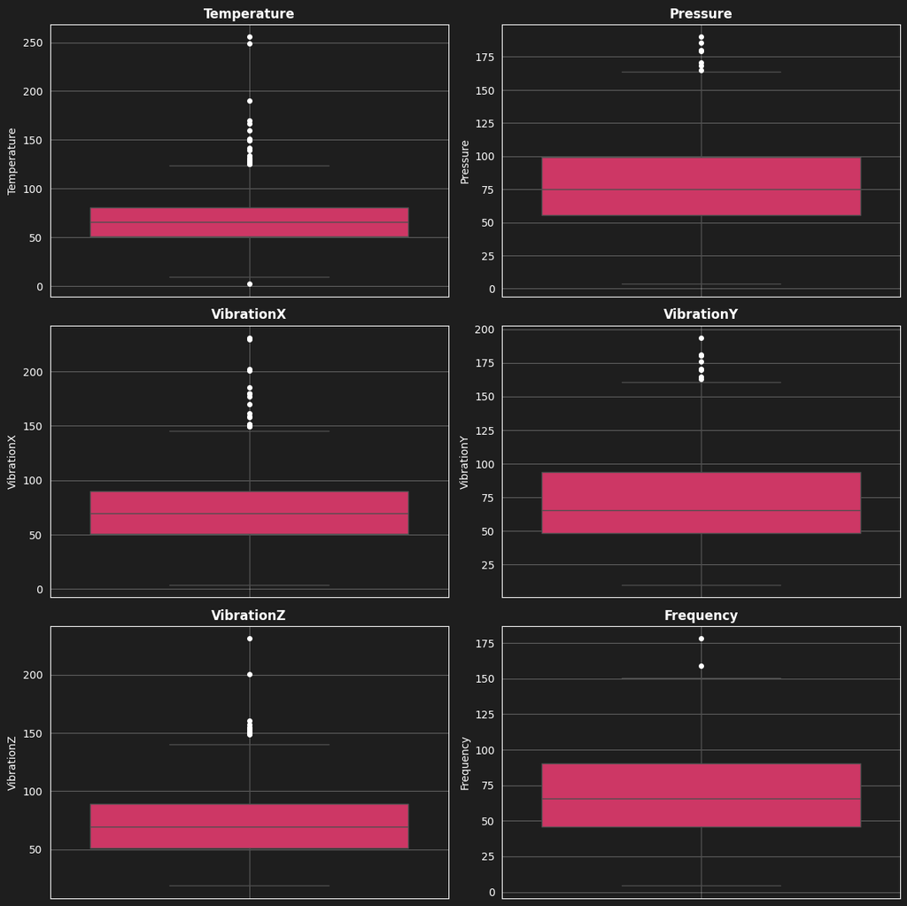

```python
# Plotting boxplots to see sensored data distributions
fig = DataPlotter().plot_multiple_boxplots(df, columns=sensor_columns)
```

Possibly, these outliers are related to failure events, where the equipment may suffer from overheat or vibration anomalies.

The correlation matrix below is provided to help understand how the variables are related.

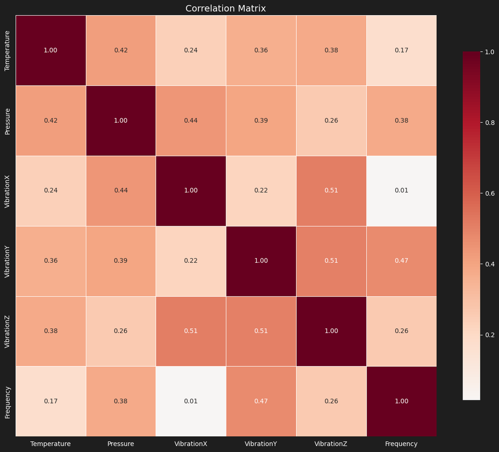

```python
fig = DataPlotter().plot_correlation_heatmap(df[sensor_columns], figsize=(12, 10))
```

**Moderate Correlations:**

- VibrationY-VibrationZ: 0.51, makes sense because they are sensoring the same effect on the equipment
- VibrationX-VibrationZ: 0.51, makes sense because they are sensoring the same effect on the equipment
- VibrationY-Frequency: 0.47
- Pressure-VibrationX: 0.44

**Weak Correlations:**

**No strong correlations (>0.6)** indicates each sensor captures distinct aspects of equipment behavior

As this study deals with data over time, it is important to check how variables behave through the operation cycles.

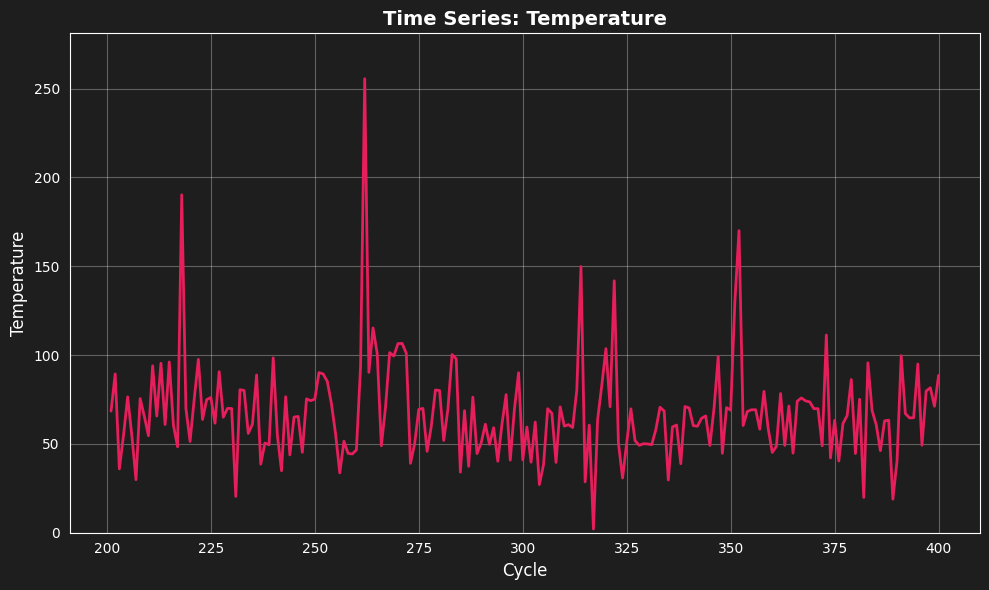

```python
# Plotting time series for Temperature. Filtering the DataFrame to a specific range for clarity
fig = DataPlotter().plot_time_series(df.iloc[200:400], 'Temperature')
```

Given the high variability and noise in the time series, smoothing techniques can be useful to simplify visualizations and improve interpretability.

Moving average is a simple and direct option to reduce noise and highlight overall trends in the data.

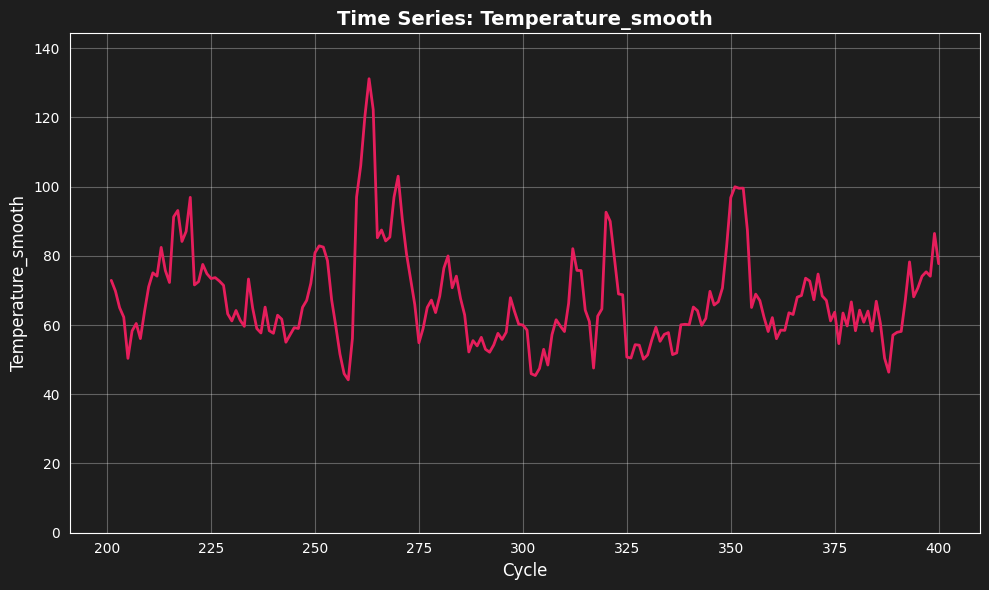

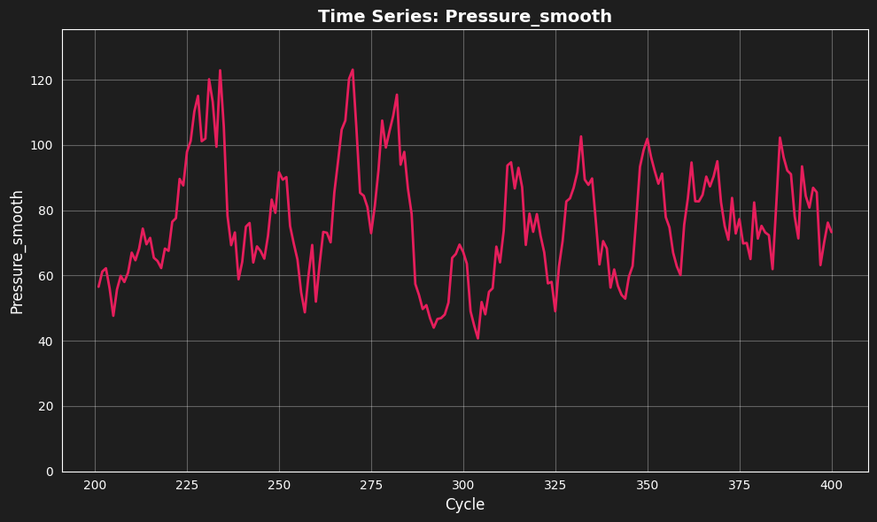

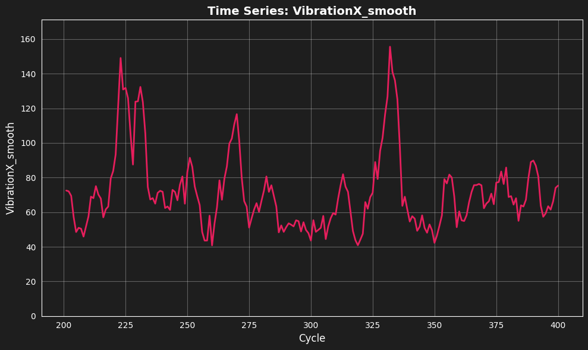

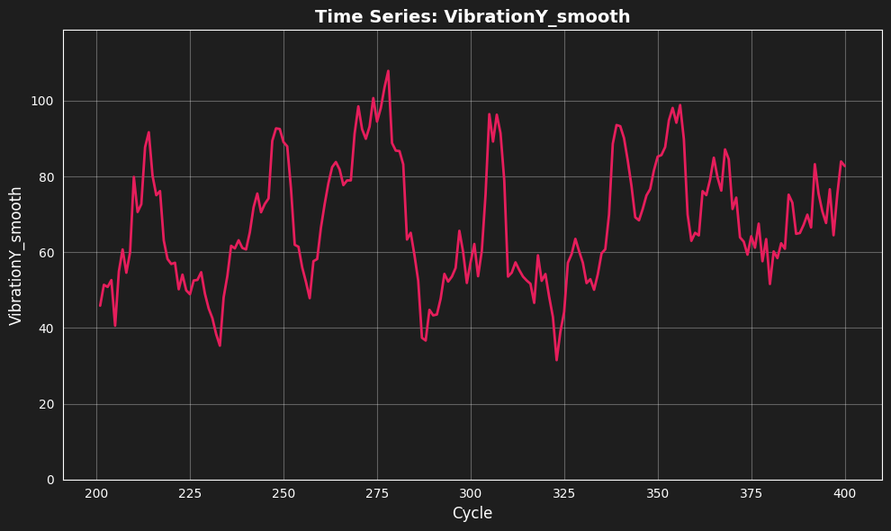

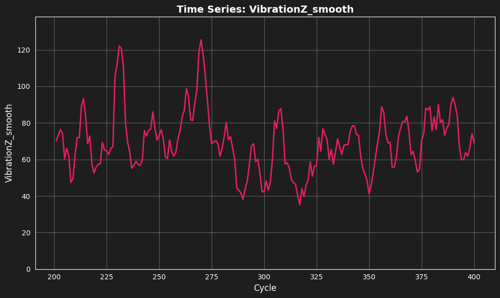

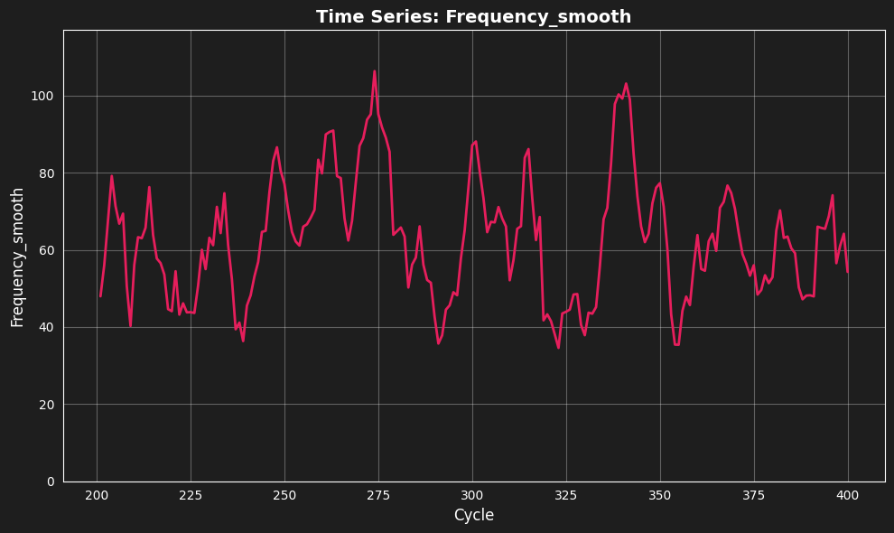

```python
# Plotting time series for all variables. Filtering the DataFrame to a specific range for clarity
smooth_df = df.copy()
for col in sensor_columns:
    smooth_df[f'{col}_smooth'] = smooth_df[col].rolling(window=5, center=True).mean()
    DataPlotter().plot_time_series(smooth_df.iloc[200:400], f'{col}_smooth')
```

The above time series are plotting data from Cycles 200 to 400 for better visualization. Even though it doesn't represente the entire dataset, it gives valuable insights about how the sensored variables changes over time.

**Variable-Specific Behaviors:**

- Temperature: Very sharp and short spikes
- Pressure and VibrationZ: High peaks with continuous cycles of increases and decreases
- VibrationX: Very high peaks, takes longer to go back to normal
- VibrationY: Volatile with big plateaus
- Frequency: Sequence of plateaus, but generally the same baseline

### Key Findings – Section 3: Sensor Data

**Outlier Patterns:**

**Correlation Analysis:**

**Time Series Patterns:**

- **Synchronized peaks** aligned with failures.
- **Sensor-specific behaviors**:
  - **Temperature**: Sharp, brief spikes (thermal events)
  - **Pressure & VibrationZ**: Long, fluctuating peaks
  - **VibrationX**: High peaks with slow recovery
  - **VibrationY**: Volatile with extended plateaus
  - **Frequency**: Plateaus with stable baseline

**Predictive Insights:**

- **Outliers** marking failure events.
- **All sensors matter**: Each one shows a different failure pattern.
- **Strong early warning signals** come from synchronized sensor spikes.

# 4. Setup parameters analysis

This section examines the distribution of configuration parameters (Preset_1 and Preset_2) and how their relate with sensored data.

```python
# Preset_1 and Preset_2 distributions
print(df['Preset_1'].value_counts(normalize=True)*100)
print(df['Preset_2'].value_counts(normalize=True)*100)
```

```
Preset_1
2    35.125
1    33.000
3    31.875
Name: proportion, dtype: float64
Preset_2
7    13.625
6    12.625
2    12.625
3    12.625
5    12.500
8    12.500
1    11.875
4    11.625
Name: proportion, dtype: float64
```

Considering the entire dataset, both variables exhibit a well-balanced distribution across their available values. Preset_1 has three unique values, each used in approximately one-third of the operation cycles. Similarly, Preset_2 has eight possible values, all of which appear with roughly equal frequency throughout the data collection period.

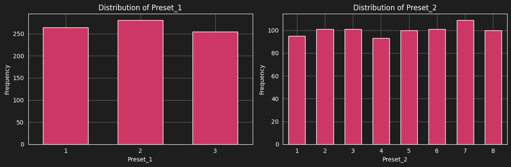

```python
fig = DataPlotter().plot_multiple_histograms(df, setup_columns)
```

In addition to analyzing data distribution, it’s useful to examine how sensor readings vary across different **Preset_1** and **Preset_2** configurations.

This can be done using basic statistics grouped by each setup

```python
def create_stats_summary(df: pd.DataFrame, target_col: Union[str, List[str]] = 'Fail_index',
                         agg_funcs: List[str] = ['mean', 'max', 'median']) -> pd.DataFrame:
    """Creates a summary DataFrame with specified aggregation functions for each sensor column.
    Args:
        df (pd.DataFrame): DataFrame containing the data.
        target_col (Union[str, List[str]]): Target column name(s) for grouping.
        agg_funcs (List[str]): List of aggregation functions to apply.
    Returns:
        pd.DataFrame: DataFrame with aggregated statistics.
    """
    # Get float columns for sensor data
    sensored_cols = df.select_dtypes(include=['float64']).columns.tolist()

    # Create aggregation dictionary
    agg_dict = {col: agg_funcs for col in sensored_cols}

    # Handle single or multiple target columns for count
    if isinstance(target_col, str):
        agg_dict[target_col] = 'count'  # duration in operation cycles
    elif isinstance(target_col, list):
        # For multiple columns, use the first one for count
        agg_dict[target_col[0]] = 'count'

    # Group by target column(s) and aggregate
    result_df = df.groupby(target_col).agg(agg_dict)

    return result_df
```

```python
# Statistics summary grouped by Preset_1
stats_preset_1 = create_stats_summary(df, target_col='Preset_1', agg_funcs=['mean','max','std'])
display(stats_preset_1)
```

| Preset_1 | Temperature mean | Temperature max | Temperature std | Pressure mean | Pressure max | Pressure std | VibrationX mean | VibrationX max | VibrationX std | VibrationY mean | VibrationY max | VibrationY std | VibrationZ mean | VibrationZ max | VibrationZ std | Frequency mean | Frequency max | Frequency std | Preset_1 count |
| --- | --- | --- | --- | --- | --- | --- | --- | --- | --- | --- | --- | --- | --- | --- | --- | --- | --- | --- | --- |
| 1 | 68.967760 | 255.6078 | 27.625229 | 79.123766 | 189.9957 | 34.065839 | 72.313917 | 230.8611 | 31.496779 | 74.692277 | 193.5699 | 35.875123 | 72.576147 | 230.9511 | 30.599606 | 70.001825 | 178.0903 | 29.380002 | 264 |
| 2 | 69.942106 | 190.2445 | 24.700500 | 78.168480 | 185.4064 | 29.395388 | 74.500814 | 202.3607 | 29.280197 | 73.914876 | 170.5197 | 32.233641 | 73.327357 | 154.2559 | 27.147181 | 68.578242 | 146.1972 | 28.865416 | 281 |
| 3 | 68.821858 | 149.8732 | 24.243219 | 79.781719 | 179.3932 | 34.168029 | 74.755356 | 230.1534 | 33.044046 | 69.571219 | 180.6042 | 29.635480 | 69.521098 | 153.3271 | 25.467266 | 65.991335 | 158.8117 | 29.157760 | 255 |

On **Preset_1** the three groups have similar averages, but in some variables the STD and maximum values differs signifcantly, indicatin setups with more variability.

**Preset_1=1**, for example, have higher STD and maximum value on **Temperature**, **VibrationY**, **VibrationZ** and **Frequency**.

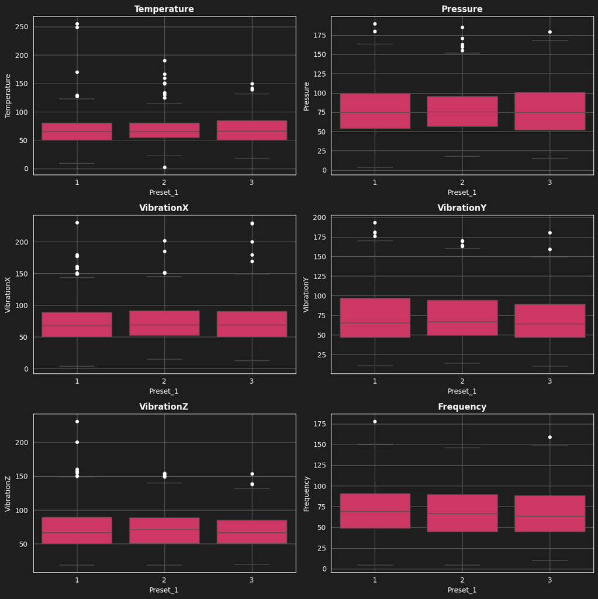

```python
fig = DataPlotter().plot_multiple_boxplots(df, sensor_columns, 'Preset_1')
```

Although, based on the boxplots, there is no evident pattern on the behavio of sensored data during different setups of **Preset_1**.

Besides that, the boxplot shows great amount of outliers on the majority of variables, which once again can be good indicators of failures.

```python
# Statistics summary grouped by Preset_2
stats_preset_2 = create_stats_summary(df, target_col='Preset_2', agg_funcs=['mean','max','std'])
display(stats_preset_2)
```

| Preset_2 | Temperature mean | Temperature max | Temperature std | Pressure mean | Pressure max | Pressure std | VibrationX mean | VibrationX max | VibrationX std | VibrationY mean | VibrationY max | VibrationY std | VibrationZ mean | VibrationZ max | VibrationZ std | Frequency mean | Frequency max | Frequency std | Preset_2 count |
| --- | --- | --- | --- | --- | --- | --- | --- | --- | --- | --- | --- | --- | --- | --- | --- | --- | --- | --- | --- |
| 1 | 74.158033 | 190.2445 | 23.316243 | 87.437528 | 185.4064 | 35.665917 | 77.603592 | 179.9289 | 31.349185 | 76.590235 | 180.3946 | 33.748140 | 74.414243 | 129.9870 | 24.371564 | 67.556556 | 158.8117 | 28.819870 | 95 |
| 2 | 65.171999 | 125.0366 | 20.915388 | 74.072082 | 179.3932 | 30.331943 | 73.855507 | 230.1534 | 32.268890 | 72.488248 | 180.6042 | 35.631444 | 73.079167 | 160.2396 | 31.722912 | 68.191610 | 150.4209 | 28.226456 | 101 |
| 3 | 66.050987 | 150.6411 | 23.739138 | 75.622961 | 170.8769 | 29.997944 | 74.375486 | 200.7496 | 34.245235 | 70.586917 | 150.1817 | 28.819449 | 68.505925 | 150.4372 | 25.762196 | 68.645790 | 125.2546 | 24.866747 | 101 |
| 4 | 66.740711 | 139.1715 | 24.288486 | 76.475139 | 160.4336 | 32.320485 | 70.947501 | 230.8611 | 31.772092 | 68.211023 | 160.7772 | 30.384462 | 67.950515 | 230.9511 | 30.535245 | 62.205503 | 129.2105 | 27.792579 | 93 |
| 5 | 70.762358 | 159.5474 | 22.843758 | 81.700494 | 189.9957 | 31.385660 | 73.272888 | 151.0231 | 26.717686 | 78.716511 | 193.5699 | 35.677940 | 73.310177 | 133.2272 | 25.665243 | 71.378600 | 178.0903 | 30.236944 | 100 |
| 6 | 65.562944 | 170.0762 | 25.474188 | 77.232329 | 168.4883 | 33.523970 | 71.536644 | 179.8780 | 31.626552 | 64.525669 | 160.7635 | 30.897058 | 71.923695 | 200.2427 | 30.929261 | 64.368146 | 145.7225 | 32.763257 | 101 |
| 7 | 73.618665 | 255.6078 | 30.292093 | 82.221614 | 165.1597 | 33.667497 | 75.183180 | 202.3607 | 30.090060 | 78.745074 | 180.8705 | 34.031220 | 74.343539 | 157.0836 | 25.741752 | 74.894706 | 149.4957 | 29.905307 | 109 |
| 8 | 71.828459 | 249.2077 | 30.144477 | 77.277325 | 159.9854 | 31.879289 | 73.989731 | 229.2359 | 31.973178 | 71.872561 | 169.7738 | 30.098922 | 71.053681 | 151.9750 | 27.367860 | 67.526305 | 148.4044 | 28.865203 | 100 |

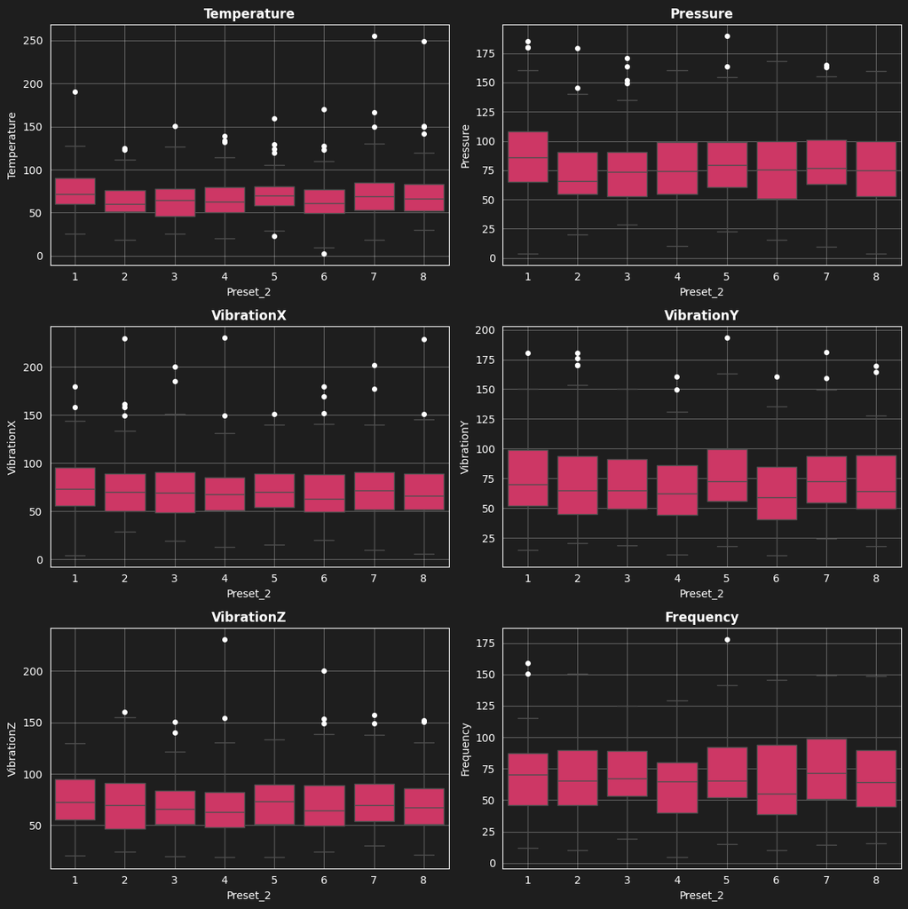

```python
fig = DataPlotter().plot_multiple_boxplots(df, sensor_columns, 'Preset_2')
```

Overall, there is **no clear or consistent pattern** linking **Preset_2** to major shifts in the sensor values.

This is suggesting that configuration alone does not strongly affect sensor readings. On the other hand, specific combinatios of **Preset_** and **Preset_2** could have this effect and must be investigated.

```python
stats_preset_1_2 = create_stats_summary(df, target_col=['Preset_1','Preset_2'], agg_funcs=['mean', 'max', 'std'])
display(stats_preset_1_2)
```

| Preset_1 | Preset_2 | Temperature mean | Temperature max | Temperature std | Pressure mean | Pressure max | Pressure std | VibrationX mean | VibrationX max | VibrationX std | VibrationY mean | VibrationY max | VibrationY std | VibrationZ mean | VibrationZ max | VibrationZ std | Frequency mean | Frequency max | Frequency std | Preset_1 count |
| --- | --- | --- | --- | --- | --- | --- | --- | --- | --- | --- | --- | --- | --- | --- | --- | --- | --- | --- | --- | --- |
| 1 | 1 | 73.672691 | 127.2417 | 20.177569 | 94.887344 | 179.8189 | 41.686566 | 77.173021 | 158.5565 | 35.067217 | 82.175776 | 180.3946 | 37.781718 | 73.740894 | 123.8469 | 23.618719 | 66.742000 | 150.5588 | 31.277789 | 34 |
|  | 2 | 64.246879 | 122.6822 | 21.777069 | 76.396842 | 145.2697 | 27.409190 | 74.977545 | 161.1887 | 30.102813 | 74.506895 | 176.1979 | 39.141146 | 72.412847 | 160.2396 | 35.966658 | 72.706134 | 150.4209 | 29.592626 | 38 |
|  | 3 | 61.000637 | 99.9621 | 19.296006 | 72.083977 | 163.8401 | 30.681525 | 69.566902 | 151.0465 | 31.571214 | 64.561516 | 112.9728 | 26.168671 | 66.789765 | 150.4372 | 26.666245 | 69.359840 | 125.2546 | 26.527197 | 43 |
|  | 4 | 59.647277 | 89.3978 | 20.752920 | 81.002568 | 160.4336 | 42.188204 | 75.168818 | 230.8611 | 44.322260 | 76.714400 | 160.7772 | 42.581506 | 71.341550 | 230.9511 | 44.859027 | 61.583036 | 110.9193 | 27.018753 | 22 |
|  | 5 | 73.170077 | 129.2784 | 22.480826 | 83.011145 | 189.9957 | 34.545917 | 73.344252 | 124.8473 | 24.007260 | 81.221103 | 193.5699 | 42.072178 | 76.385916 | 119.1361 | 25.089743 | 74.447000 | 178.0903 | 36.251108 | 31 |
|  | 6 | 70.859053 | 170.0762 | 29.325379 | 74.689162 | 140.4712 | 33.449228 | 65.468015 | 179.8780 | 30.221657 | 68.135800 | 135.5254 | 32.915756 | 71.217626 | 200.2427 | 35.303416 | 65.480618 | 125.8356 | 29.240810 | 34 |
|  | 7 | 72.016918 | 255.6078 | 37.703605 | 80.604476 | 148.1710 | 31.438667 | 72.375761 | 177.1230 | 31.339244 | 83.375305 | 180.8705 | 37.637028 | 78.607382 | 157.0836 | 30.060606 | 78.998853 | 149.4957 | 28.521864 | 38 |
|  | 8 | 79.660213 | 249.2077 | 41.125180 | 70.917083 | 124.7489 | 29.545782 | 71.787117 | 129.3535 | 26.948163 | 67.788650 | 124.2531 | 24.127755 | 70.137788 | 126.7257 | 21.722589 | 65.623600 | 113.7843 | 23.449529 | 24 |
| 2 | 1 | 74.485177 | 190.2445 | 29.000095 | 81.191173 | 185.4064 | 30.289627 | 76.001467 | 128.3579 | 25.674693 | 71.602953 | 150.6206 | 31.289697 | 72.672487 | 129.9870 | 26.386166 | 70.372617 | 110.6725 | 27.649589 | 30 |
|  | 2 | 66.291797 | 125.0366 | 21.474565 | 72.709979 | 135.2812 | 28.992047 | 70.331303 | 121.9652 | 26.770742 | 72.934679 | 170.5197 | 35.375820 | 73.119538 | 150.8069 | 31.267374 | 70.451297 | 129.1288 | 25.127391 | 34 |
|  | 3 | 75.728181 | 150.6411 | 27.703815 | 89.046662 | 170.8769 | 33.965453 | 83.981165 | 185.1342 | 32.480486 | 82.956477 | 150.1817 | 33.042743 | 78.652715 | 140.3337 | 23.977727 | 71.065742 | 121.4533 | 21.872116 | 26 |
|  | 4 | 68.921107 | 133.5767 | 22.754741 | 70.310012 | 129.4164 | 24.369609 | 68.352322 | 116.5148 | 20.168569 | 63.621925 | 115.3709 | 24.991522 | 65.602565 | 154.2559 | 24.546063 | 63.796712 | 129.2105 | 31.817676 | 40 |
|  | 5 | 70.108928 | 159.5474 | 23.123858 | 79.381923 | 145.6189 | 25.919170 | 75.081050 | 151.0231 | 31.505218 | 81.819860 | 163.1468 | 32.869009 | 74.521092 | 133.2272 | 26.897304 | 68.576035 | 120.3171 | 26.134499 | 40 |
|  | 6 | 60.374351 | 109.5345 | 21.943006 | 76.004876 | 150.5028 | 30.319149 | 72.007657 | 151.5853 | 33.600363 | 63.608773 | 160.7635 | 30.670562 | 73.986265 | 148.8385 | 29.402221 | 63.091005 | 145.7225 | 32.698245 | 37 |
|  | 7 | 77.946295 | 166.3615 | 27.359169 | 82.675495 | 162.7918 | 30.801163 | 78.211262 | 202.3607 | 32.894702 | 76.188381 | 147.1967 | 31.747529 | 69.654800 | 121.0841 | 20.615471 | 74.688635 | 146.1972 | 33.554871 | 37 |
|  | 8 | 68.033986 | 150.8803 | 22.871420 | 77.929838 | 159.9854 | 30.881194 | 75.256086 | 150.7474 | 29.560332 | 80.950754 | 169.7738 | 34.272414 | 80.381405 | 151.9750 | 31.551865 | 68.202638 | 134.3847 | 28.576402 | 37 |
| 3 | 1 | 74.373752 | 113.8160 | 21.028222 | 85.311623 | 151.5770 | 32.875031 | 79.626274 | 179.9289 | 32.900583 | 75.290558 | 133.1730 | 31.465512 | 76.838326 | 124.9703 | 23.766484 | 65.724719 | 158.8117 | 27.842473 | 31 |
|  | 2 | 65.071359 | 106.7484 | 19.734678 | 72.622793 | 179.3932 | 35.925905 | 76.517076 | 230.1534 | 40.652597 | 69.319721 | 180.6042 | 31.917481 | 73.904945 | 131.6066 | 27.039644 | 59.626738 | 129.6155 | 28.884217 | 29 |
|  | 3 | 64.974675 | 126.6592 | 24.070024 | 69.471716 | 133.4898 | 22.124987 | 73.032406 | 200.7496 | 38.346860 | 68.633281 | 140.5664 | 26.235591 | 62.567747 | 115.1043 | 24.228848 | 65.720075 | 124.3949 | 25.318999 | 32 |
|  | 4 | 68.961345 | 139.1715 | 28.039199 | 81.217126 | 146.7312 | 33.115010 | 71.300345 | 149.7185 | 34.199307 | 68.097784 | 120.7242 | 25.863056 | 68.573587 | 130.4302 | 25.520281 | 60.594081 | 121.5980 | 23.137656 | 31 |
|  | 5 | 69.089872 | 123.9591 | 23.428126 | 83.497483 | 163.9099 | 35.434060 | 70.702586 | 117.9162 | 22.635379 | 71.758707 | 129.6917 | 32.070497 | 68.352090 | 130.1581 | 24.674280 | 71.964193 | 139.1930 | 29.176350 | 29 |
|  | 6 | 65.959950 | 122.9100 | 24.371998 | 81.628443 | 168.4883 | 37.835909 | 77.833507 | 169.7822 | 30.393997 | 61.565027 | 120.1073 | 29.423938 | 70.180070 | 153.3271 | 28.251191 | 64.682483 | 143.7687 | 37.385029 | 30 |
|  | 7 | 70.699374 | 110.4971 | 23.662477 | 83.535074 | 165.1597 | 39.515375 | 75.025618 | 131.3622 | 25.732398 | 76.352394 | 159.4235 | 32.627094 | 74.680518 | 137.8651 | 25.419006 | 70.531974 | 121.2473 | 27.339469 | 34 |
|  | 8 | 70.608803 | 149.8732 | 28.175358 | 80.572269 | 159.9787 | 34.333247 | 74.143772 | 229.2359 | 37.300161 | 65.773092 | 127.7148 | 27.679125 | 62.767928 | 130.2146 | 23.809747 | 68.055551 | 148.4044 | 32.576558 | 39 |

```python
# Displaying highest values for each sensor column in the stats DataFrame
for col in sensor_columns:
    print(f"Highest mean {col}:", stats_preset_1_2[(col),('mean')].idxmax())
    print(f"Highest max {col}:", stats_preset_1_2[(col),('max')].idxmax())
    print(f"Highest std {col}:", stats_preset_1_2[(col),('std')].idxmax())
    print('\n')
```

```
Highest mean Temperature: (np.int64(1), np.int64(8))
Highest max Temperature: (np.int64(1), np.int64(7))
Highest std Temperature: (np.int64(1), np.int64(8))


Highest mean Pressure: (np.int64(1), np.int64(1))
Highest max Pressure: (np.int64(1), np.int64(5))
Highest std Pressure: (np.int64(1), np.int64(4))


Highest mean VibrationX: (np.int64(2), np.int64(3))
Highest max VibrationX: (np.int64(1), np.int64(4))
Highest std VibrationX: (np.int64(1), np.int64(4))


Highest mean VibrationY: (np.int64(1), np.int64(7))
Highest max VibrationY: (np.int64(1), np.int64(5))
Highest std VibrationY: (np.int64(1), np.int64(4))


Highest mean VibrationZ: (np.int64(2), np.int64(8))
Highest max VibrationZ: (np.int64(1), np.int64(4))
Highest std VibrationZ: (np.int64(1), np.int64(4))


Highest mean Frequency: (np.int64(1), np.int64(7))
Highest max Frequency: (np.int64(1), np.int64(5))
Highest std Frequency: (np.int64(3), np.int64(6))
```

**Preset_1 = 1**  
Consistently linked to **high values across most metrics**, especially:

- Temperature: **mean**, **max**, **std**
- Pressure: **mean**, **max**, **std**
- VibrationY **mean**, **max**, **std**

**Preset_1 = 1**, combined with **Preset_2 = 4, 7, or 8**, is associated with the most intense sensor behavior — suggesting these configurations may push the equipment closer to operational limits or failure conditions.

### Key Findings of Section 4: Setup Data Analysis

**Overall Distribution:**

- Both Preset_1 and Preset_2 show balanced distributions across all values during normal operations

**Individual Risk Levels:**

- **Preset_1=1**: Higher sensor variability and maximum values (riskier configuration)
- **Combination effects are significant** - specific preset pairs create notably different sensor behaviors
- Preset_1=1 consistently linked to higher Temperature, Pressure, and VibrationY readings

**Critical Combinations:**

- **High-Risk**: Preset_1=1 + Preset_2=4/7/8 show the most intense sensor behavior

**Operational Insight:**

- Configuration combinations matter more than individual settings
- Preset_1=1 combinations should be monitored more closely during critical operations

Now, with a better understanding of the sensor variables and equipment configurations, we can analyze the distribution of failure events and their relationship with the dataset variables.

This analysis will help interpret the causes of these events and improve the chances of accurately predicting them.

# 5. Failure events analysis

## 5.1 Failure distribution

```
Fail
False    734
True      66
Name: count, dtype: int64


Fail
False    91.75
True      8.25
Name: proportion, dtype: float64
```

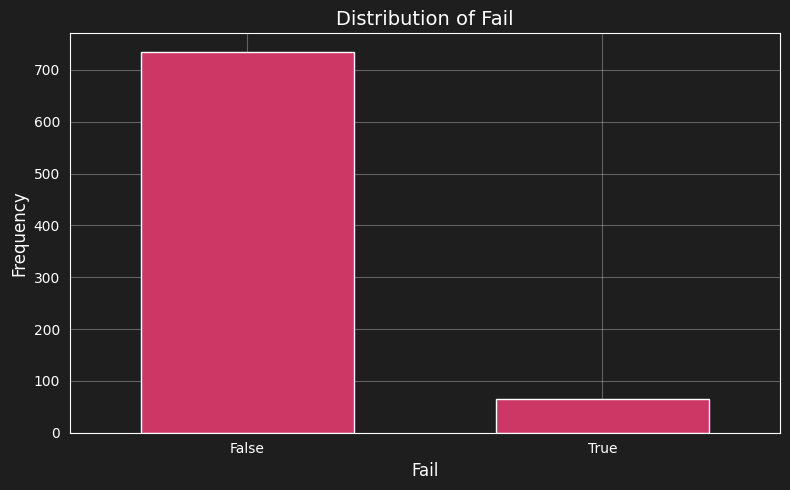

```python
print(df['Fail'].value_counts())
print('\n')
print(df['Fail'].value_counts(normalize=True)*100)

fig = DataPlotter(figsize=(8,5)).plot_histogram(df, 'Fail')
```

According to the data, it is possible to affirm that the equipment was in a failure state for approximately **8.25%** of the time or **66** operation cycles.

As expected, the target variable is imbalanced, since equipment failure is a relatively rare event. However, the failure state is precisely what needs to be predicted. For this reason, it is essential to understand the equipment’s behavior during failure, despite the smaller amount of available data.

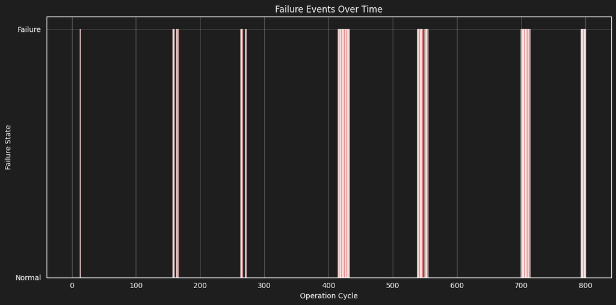

```python
# Simple bar plot showing failure events over time
fig, ax = plt.subplots(figsize=(12, 6))

# Create a simple time series showing failure state
failure_over_time = df['Fail'].astype(int)  # Convert boolean to 0/1

# Plot as bar chart
ax.bar(failure_over_time.index, failure_over_time,
       color=['red' if x == 1 else 'lightblue' for x in failure_over_time],
       alpha=0.7, width=1)

ax.set_xlabel('Operation Cycle')
ax.set_ylabel('Failure State')
ax.set_title('Failure Events Over Time')
ax.set_yticks([0, 1])
ax.set_yticklabels(['Normal', 'Failure'])

# Add grid for better readability
ax.grid(True, alpha=0.3)

plt.tight_layout()
plt.show()
```

When examining these events over a timeline, the intervals between failures appear consistent, suggesting possible seasonal patterns. Additionally, the data shows an increase in the duration of failure events throughout the analyzed period.

### Key Findings of Section 5.1. Failure distribution

- **Failure Events:** The equipment was in fail state for 66 of 800 operation cycles (~8.25% of total time).
- Seasonal pattern on occurence of failures, but recent trend of longer durations.

## 5.2 Behavior of sensored variables during failures

First, the numeric variables, such as Temperature and Pressure, will be analyzed. This section aims to identify significant differences in their values between normal and failure states.

```python
# Calculate statistics by failure state
stats_by_failure_state = create_stats_summary(df, target_col='Fail', agg_funcs=['mean', 'median', 'std']).drop(columns=['Fail'])
display(stats_by_failure_state)
```

| Fail | Temperature mean | Temperature median | Temperature std | Pressure mean | Pressure median | Pressure std | VibrationX mean | VibrationX median | VibrationX std | VibrationY mean | VibrationY median | VibrationY std | VibrationZ mean | VibrationZ median | VibrationZ std | Frequency mean | Frequency median | Frequency std |
| --- | --- | --- | --- | --- | --- | --- | --- | --- | --- | --- | --- | --- | --- | --- | --- | --- | --- | --- |
| False | 67.176883 | 64.81490 | 24.824880 | 75.632790 | 71.91120 | 30.561616 | 71.494801 | 66.35860 | 30.415829 | 68.318454 | 63.51685 | 29.010220 | 68.796673 | 65.00595 | 25.678027 | 65.382993 | 62.6873 | 27.943439 |
| True | 92.469126 | 90.92895 | 21.683668 | 116.422541 | 110.61915 | 30.040055 | 100.167188 | 98.04375 | 28.109402 | 122.481161 | 122.11510 | 30.861776 | 106.003211 | 99.66940 | 28.377487 | 99.812742 | 99.2127 | 22.960576 |

```python
stats_by_failure_state = create_stats_summary(df, target_col='Fail', agg_funcs=['mean','max','std']).drop(columns=['Fail'])
display(stats_by_failure_state)
```

| Fail | Temperature mean | Temperature max | Temperature std | Pressure mean | Pressure max | Pressure std | VibrationX mean | VibrationX max | VibrationX std | VibrationY mean | VibrationY max | VibrationY std | VibrationZ mean | VibrationZ max | VibrationZ std | Frequency mean | Frequency max | Frequency std |
| --- | --- | --- | --- | --- | --- | --- | --- | --- | --- | --- | --- | --- | --- | --- | --- | --- | --- | --- |
| False | 67.176883 | 255.6078 | 24.824880 | 75.632790 | 185.4064 | 30.561616 | 71.494801 | 230.8611 | 30.415829 | 68.318454 | 176.1979 | 29.010220 | 68.796673 | 230.9511 | 25.678027 | 65.382993 | 158.8117 | 27.943439 |
| True | 92.469126 | 150.8803 | 21.683668 | 116.422541 | 189.9957 | 30.040055 | 100.167188 | 200.7496 | 28.109402 | 122.481161 | 193.5699 | 30.861776 | 106.003211 | 200.2427 | 28.377487 | 99.812742 | 178.0903 | 22.960576 |

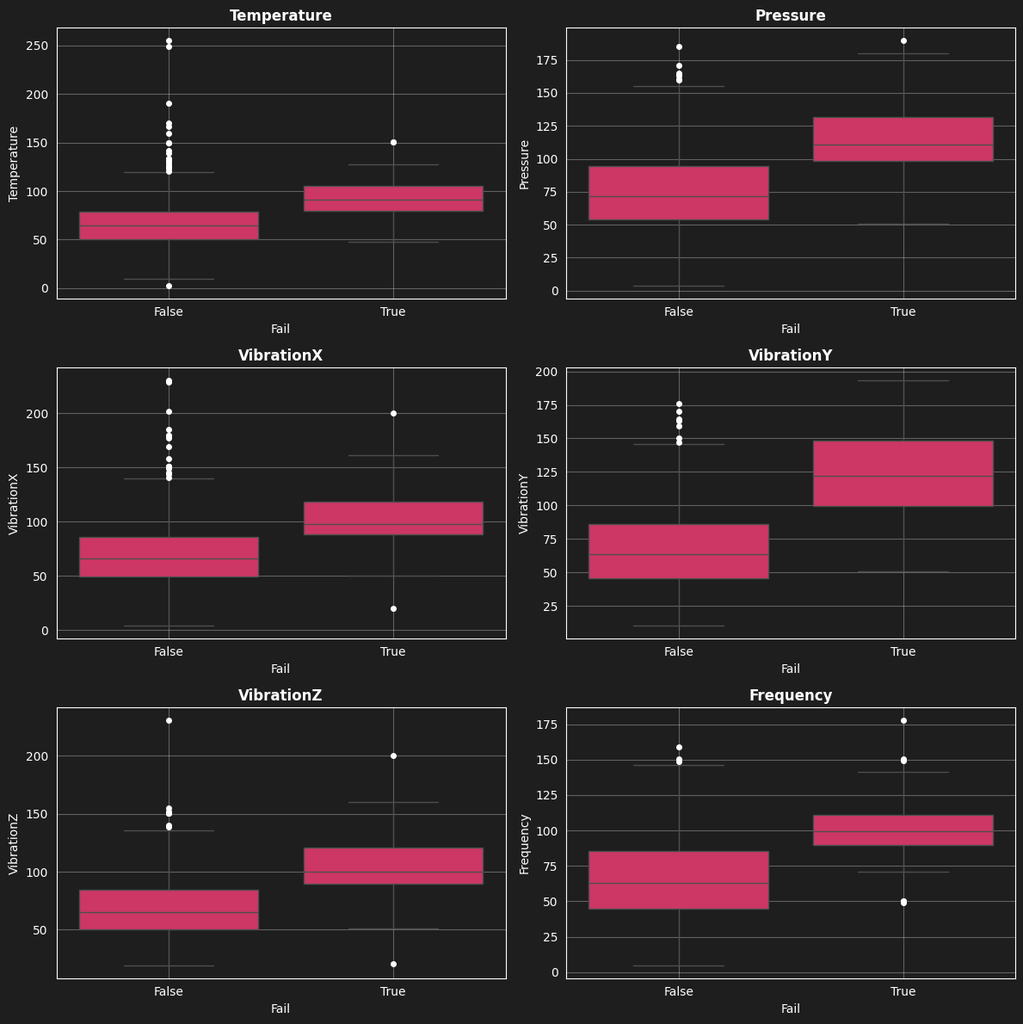

```python
# Boxplot for each numeric column grouped by 'Fail'
# This will help visualize the distribution of each feature for both failure states
fig = DataPlotter().plot_multiple_boxplots(df, df.select_dtypes(float).columns.tolist(), 'Fail')
```

Among them, **VibrationY** and **Pressure** demonstrate the most significant differences between normal and failure conditions. This shows their potential importance in failure detection and suggests they may play a critical role in the feature importance analysis of the machine learning model to be developed.

One simple way to quantify these difference is calculating the mean differences of each variable in normal and failure state.

```python
def mean_difference_by_target(df: pd.DataFrame, columns: List[str], target: str = 'Fail') -> pd.Series:
    """
    Calculates the mean difference for the specified columns between True and False states of the target variable.

    Args:
        df (pd.DataFrame): The dataframe containing the data.
        columns (list): List of column names to calculate mean difference for.
        target (str): The binary target column name.

    Returns:
        pd.Series: Mean difference (True - False) for each column.
    """
    assert target in df.columns, f"Target column '{target}' not found in DataFrame."
    assert all(col in df.columns for col in columns), "One or more specified columns not found in DataFrame."

    means_true = df[df[target] == True][columns].mean()
    means_false = df[df[target] == False][columns].mean()

    return means_true - means_false
```

```python
# Calculate mean differences for float columns by target and sort results
mean_difference_by_target(df, df.select_dtypes(float).columns.tolist(), 'Fail').sort_values(ascending=False)
```

```
VibrationY     54.162707
Pressure       40.789751
VibrationZ     37.206537
Frequency      34.429749
VibrationX     28.672387
Temperature    25.292243
dtype: float64
```

Once again, the data reveals a significant increase in sensored variables during equipment failures. The mean **VibrationY** is approximately 54 units higher and mean **Pressure** is 40 units higher when the equipment is in a failure state.

## 5.3 Distribution of setup parameters during failures

The setup variables Preset_1 and Preset_2 define how the equipment is configured during an operation cycle. Analyzing their relationship with failure occurrences is essential to identify configuration combinations that are more likely to result in failures.

When isolating the operation cycles with failure, certain setup parameters appear more frequently, such as values 1 and 2 for **Preset_1**, and 1 and 5 for **Preset_2**. Conversely, parameter 4 on **Preset_2** is relatively uncommon in failure events.

```python
# Preset_1 and Preset_2 distributions considering only failure events
print(df.query('Fail == True')['Preset_1'].value_counts(normalize=True)*100)
print(df.query('Fail == True')['Preset_2'].value_counts(normalize=True)*100)
```

```
Preset_1
1    40.909091
2    31.818182
3    27.272727
Name: proportion, dtype: float64
Preset_2
5    18.181818
1    16.666667
2    13.636364
6    13.636364
7    13.636364
8    10.606061
3     9.090909
4     4.545455
Name: proportion, dtype: float64
```

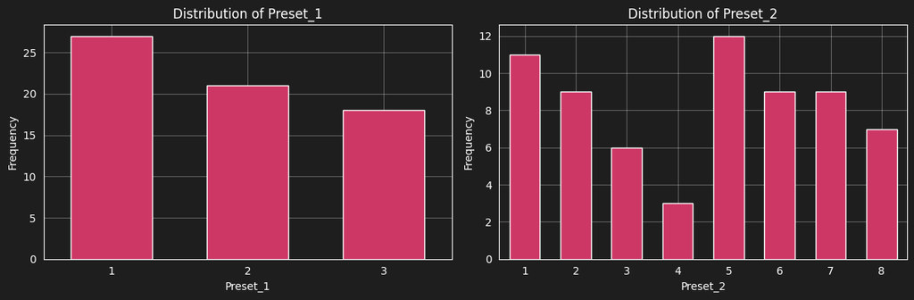

```python
# Plotting histograms for Preset_1 and Preset_2 for failure events
fig = DataPlotter().plot_multiple_histograms(df.query("Fail == True"), ['Preset_1','Preset_2'])
```

Taking it a step further, specific combinations of **Preset_1** and **Preset_2** configurations may be correlated with failure events. To visualize this relationship, a heatmap can be used to show how the proportion of failures varies across different equipment setup combinations.

```python
# Grouping by Preset_1 and calculating failure rate and number of cycles with failure
print(df.groupby(['Preset_1']).agg({'Fail': ['mean', 'sum']}).rename(columns={'mean': 'Failure Rate', 'sum': 'Cycles with Failure'}))
print('\n')
# Grouping by Preset_2 and calculating failure rate and number of cycles with failure
print(df.groupby(['Preset_2']).agg({'Fail': ['mean', 'sum']}).rename(columns={'mean': 'Failure Rate', 'sum': 'Cycles with Failure'}))
```

```
                 Fail
         Failure Rate Cycles with Failure
Preset_1
1            0.102273                  27
2            0.074733                  21
3            0.070588                  18


                 Fail
         Failure Rate Cycles with Failure
Preset_2
1            0.115789                  11
2            0.089109                   9
3            0.059406                   6
4            0.032258                   3
5            0.120000                  12
6            0.089109                   9
7            0.082569                   9
8            0.070000                   7
```

**Preset_1**

- Preset_1=1 has a higher failure rate (~10%) in comparison with the other two options.

**Preset_2**

- Preset_2=5 and Preset_2=1 appears to be risky, both with approximately 12% of failure rate.
- Preset_2=4 could be considered the safest setting, with only 3% of failure rate.

The heatmap below also reveals that certain combinations of **Preset_1** and **Preset_2** stand out with a noticeably higher occurrence of failures.

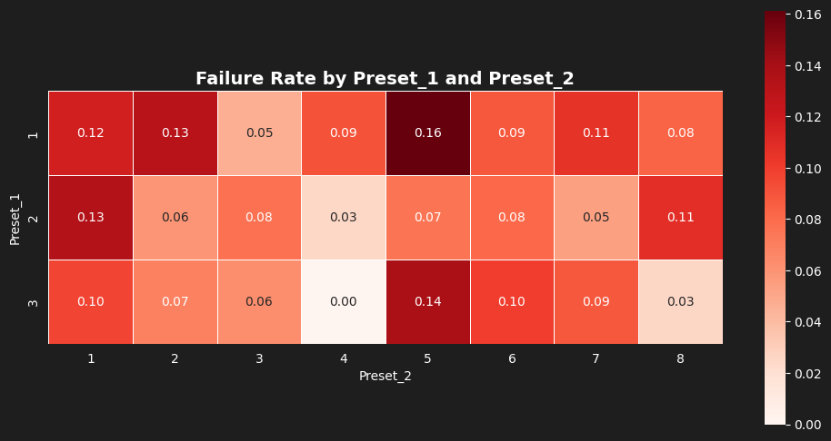

```python
# Heatmap plotting failure rates by Preset_1 and Preset_2
fig = DataPlotter().plot_failure_rate_heatmap(df, row_var='Preset_1', col_var='Preset_2', target_var='Fail')
```

**Configurations with high failure rates**:

- Preset_1=1, Preset_2=5: Highest failure rate at 16%, almost double of the mean failure rate (8.25%).
- Preset_1=3, Preset_2=5: Second highest at 14%
- Preset_1=1, Preset_2=2: Third highest at 13%

**Configurations with low failure rates**:

- Preset_1=3, Preset_2=4: Zero failures (safest combination)
- Preset_1=2, Preset_2=4: Only 3% failure rate

Without specific knowledge of how the **Preset_1** and **Preset_2** parameters control equipment operation, it is difficult to recommend direct actions to minimize failure risk on the FPSO.

Nonetheless, based on the analyzed data, it is advisable to avoid configurations associated with high failure rates, especially during critical operations or peak production periods. As a safer alternative, combinations such as Preset_1 = 3 and Preset_2 = 4, which showed lower failure occurrences, could be prioritized when possible.

These critical equipment configurations should be closely monitored alongside sensor-based variables. The combination of high-risk setups with increases in variables such as vibration and pressure may serve as early warning signals of equipment failure.

### Key Findings of Section 5.3: Distribution of setup parameters during failures

- **Balanced Overall Distribution**: Both Preset_1 (3 values) and Preset_2 (8 values) show well-balanced distributions, with each configuration used approximately equally during operations.
- **High-Risk Individual Configurations**
  - **Preset_1=1**: Higher failure rate (~10%) compared to other Preset_1 options
  - **Preset_2=5** and **Preset_2=1**: Both show risky behavior with ~12% failure rates
  - **Preset_2=4**: Safest individual setting with only 3% failure rate
- **Critical Configuration Combinations**:
  - **Preset_1=1, Preset_2=5**: Highest failure rate at 16% (nearly double the overall 8.25% rate)
  - **Preset_1=3, Preset_2=5**: Second highest at 14%
  - **Preset_1=1, Preset_2=2**: Third highest at 13%
- **Safe Configuration Combinations**:
  - **Preset_1=3, Preset_2=4**: Zero failures recorded (safest combination)
  - **Preset_1=2, Preset_2=4**: Only 3% failure rate
- **Operational Recommendations**: Avoid high-risk configurations (especially Preset_1=1 with Preset_2=5) during critical operations.
- **Early Warning Integration**: High-risk equipment configurations could be monitored alongside sensor variables, as the combination of risky setups with elevated vibration and pressure readings may serve as compound early warning signals for equipment failure.

## 5.4 Caracterizing failure events

Another important aspect of this study is identifying distinct failure events and analyzing them in terms of their duration, causes, and associated variable behavior.

The first step is to find these events and categorize them on the dataset.

```python
def find_failure_transitions(fail_series: pd.Series) -> dict:
    """
    Finds all failure transitions (starts and stops) in a boolean Series.

    Args:
        fail_series (pd.Series): A pandas Series of boolean values indicating failure state over time.

    Returns:
        dict: Dictionary containing:
            - 'starts': List of cycle ids where transitions from False to True occurred
            - 'stops': List of cycle ids where transitions from True to False occurred
            - 'events': List of tuples (start, stop) for each failure event
    """
    # Check if the input series is of boolean dtype
    if fail_series.dtype != bool:
        raise ValueError("Input series must be of boolean dtype.")

    # Use shift to 'move' rows one position down and verify previous state
    previous_state = fail_series.shift(1, fill_value=False)

    # Find transitions from False to True (failure starts)
    transition_starts = (~previous_state) & fail_series
    starts = list(transition_starts[transition_starts == True].index)

    # Find transitions from True to False (failure stops)
    transition_stops = previous_state & (~fail_series)
    stops = list(transition_stops[transition_stops == True].index)

    # If series ends with failure, add the last index as stop
    if len(starts) > len(stops):
        stops.append(fail_series.index[-1] + 1)  # Add one to include the last cycle as stop

    # Create failure events as (start, stop) tuples
    events = list(zip(starts, stops))

    return {
        'starts': starts,
        'stops': stops,
        'events': events
    }
```

```python
# Finding failure transitions in the 'Fail' column
failure_events = find_failure_transitions(df['Fail'])
display(failure_events)
```

```
{'starts': [13, 157, 163, 263, 270, 415, 538, 550, 700, 793],
 'stops': [14, 160, 166, 266, 272, 433, 547, 555, 714, np.int64(801)],
 'events': [(13, 14),
  (157, 160),
  (163, 166),
  (263, 266),
  (270, 272),
  (415, 433),
  (538, 547),
  (550, 555),
  (700, 714),
  (793, np.int64(801))]}
```

```python
n = len(failure_events['events'])
failure_duration = df['Fail'].sum()

print(f"Total duration of failure state: {failure_duration} cycles")
print(f"Total number of failure events: {n}")
print(f"Mean failure state duration per occurence: {failure_duration / n} cycles")
```

```
Total duration of failure state: 66 cycles
Total number of failure events: 10
Mean failure state duration per occurence: 6.6 cycles
```

Therefore, the data reveals a total of **10 failure events** throughout the time series, resulting in **66 operation cycles** in the failure state.

These events are detailed below to provide a clearer understanding of each individual occurrence.

```python
def label_failures(df: pd.DataFrame, failure_events: dict, fail_index_column: str = 'Fail_index') -> pd.DataFrame:
    """
    Labels the failure periods in the DataFrame with a unique index for each failure.

    Args:
        df (pd.DataFrame): DataFrame containing the failure data with 'Fail' column.
        failure_events (dict): Dictionary containing failure events with 'events' key.
        fail_index_column (str): Name of the column to store failure indices.

    Returns:
        pd.DataFrame: DataFrame with an additional 'Fail_index' column indicating failure periods.
    """
    # Initialize a new column for failure indices
    df[fail_index_column] = 0

    # Loop through each failure period and assign an index
    for i, event in enumerate(failure_events['events']):
        start, stop = event
        print(f"Failure {i+1} start at operation cycle: {start}")
        print(f"Failure {i+1} stop at operation cycle: {stop}")

        # Assigning a failure index to the DataFrame for each failure period
        mask = (df.index >= start) & (df.index < stop)
        df.loc[mask, 'Fail_index'] = i + 1

    return df
```

```python
# Applying the function to label failures in the DataFrame
df = label_failures(df, failure_events=failure_events, fail_index_column='Fail_index')
```

```
Failure 1 start at operation cycle: 13
Failure 1 stop at operation cycle: 14
Failure 2 start at operation cycle: 157
Failure 2 stop at operation cycle: 160
Failure 3 start at operation cycle: 163
Failure 3 stop at operation cycle: 166
Failure 4 start at operation cycle: 263
Failure 4 stop at operation cycle: 266
Failure 5 start at operation cycle: 270
Failure 5 stop at operation cycle: 272
Failure 6 start at operation cycle: 415
Failure 6 stop at operation cycle: 433
Failure 7 start at operation cycle: 538
Failure 7 stop at operation cycle: 547
Failure 8 start at operation cycle: 550
Failure 8 stop at operation cycle: 555
Failure 9 start at operation cycle: 700
Failure 9 stop at operation cycle: 714
Failure 10 start at operation cycle: 793
Failure 10 stop at operation cycle: 801
```

```python
# Sample of the DataFrame with failure indices indicating different failure events
df.head(15)
```

| Cycle | Preset_1 | Preset_2 | Temperature | Pressure | VibrationX | VibrationY | VibrationZ | Frequency | Fail | Fail_index |
| --- | --- | --- | --- | --- | --- | --- | --- | --- | --- | --- |
| 1 | 3 | 6 | 44.2352 | 47.6573 | 46.4418 | 64.8203 | 66.4545 | 44.4832 | False | 0 |
| 2 | 2 | 4 | 60.8072 | 63.1721 | 62.0060 | 80.7144 | 81.2464 | 60.2287 | False | 0 |
| 3 | 2 | 1 | 79.0275 | 83.0322 | 82.6421 | 98.2544 | 98.7852 | 80.9935 | False | 0 |
| 4 | 2 | 3 | 79.7162 | 100.5086 | 122.3623 | 121.3634 | 118.6525 | 80.3156 | False | 0 |
| 5 | 2 | 5 | 39.9891 | 51.7648 | 42.5143 | 61.0379 | 50.7165 | 64.2452 | False | 0 |
| 6 | 1 | 2 | 58.3361 | 64.4264 | 56.4792 | 78.6237 | 65.9115 | 78.8862 | False | 0 |
| 7 | 1 | 3 | 77.9378 | 83.1467 | 77.8006 | 109.6790 | 86.2307 | 99.6812 | False | 0 |
| 8 | 1 | 4 | 78.5635 | 130.0899 | 110.4799 | 130.9970 | 85.2186 | 98.4674 | False | 0 |
| 9 | 3 | 7 | 77.4862 | 104.4630 | 77.3904 | 159.4235 | 115.2119 | 98.9003 | False | 0 |
| 10 | 1 | 8 | 42.6192 | 48.3433 | 65.7892 | 49.5248 | 64.9151 | 41.6207 | False | 0 |
| 11 | 2 | 5 | 59.5014 | 64.4693 | 79.0678 | 65.8915 | 79.4462 | 60.2082 | False | 0 |
| 12 | 2 | 5 | 80.6625 | 84.2735 | 99.6288 | 83.7019 | 103.1410 | 77.8884 | False | 0 |
| 13 | 1 | 1 | 79.8065 | 103.1297 | 120.7531 | 134.5009 | 115.8732 | 76.5629 | True | 1 |
| 14 | 3 | 8 | 46.0122 | 30.7552 | 35.0211 | 17.8876 | 21.5113 | 44.8897 | False | 0 |
| 15 | 1 | 6 | 48.6910 | 19.9130 | 54.4553 | 25.1332 | 24.2793 | 31.1211 | False | 0 |

With the new label added to the dataset, it is now possible to quantify the duration of each event. Longer events may indicate more critical or severe failures in the equipment.

```
Median number of cycles per failure event: 4.0
```

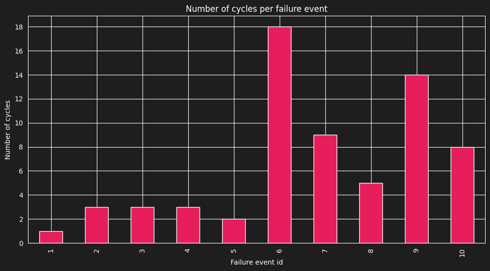

```python
from matplotlib.ticker import MaxNLocator
from matplotlib import pyplot as plt

# Plotting the number of cycles per failure event
failures = df.query('Fail == True').groupby('Fail_index').size()

print(f"Median number of cycles per failure event: {failures.median()}")

ax = failures.plot(kind='bar', figsize=(12, 6), title='Number of cycles per failure event')
ax.yaxis.set_major_locator(MaxNLocator(integer=True))
ax.set_ylabel('Number of cycles')
ax.set_xlabel('Failure event id')

plt.show()
```

This trend of increasingly prolonged failure events over time may indicate chronic issues with the FPSO equipment or operational challenges. It represents a critical concern that must be addressed to minimize the impact of extended downtime on oil extraction.

The following analysis will look at these events in greater detail to better understand their characteristics and potential root causes.

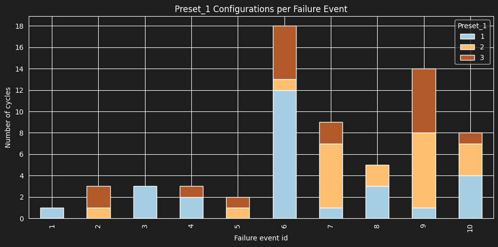

```python
fig, ax = plt.subplots(figsize=(10, 5))

# Stacked barplot for Preset_1 configurations per failure event
df.query('Fail==True').groupby(['Fail_index', 'Preset_1']).size().unstack().plot(
    kind='bar',
    stacked=True,
    colormap='Paired',
    ax=ax
)

# Adjust axes and labels
ax.yaxis.set_major_locator(MaxNLocator(integer=True))
ax.set_ylabel('Number of cycles')
ax.set_xlabel('Failure event id')
ax.set_title('Preset_1 Configurations per Failure Event')

plt.tight_layout()
plt.show()
```

The barplot reveals important operational patterns during individual failure events:

**Configuration Switching During Failures:**

- Multiple Preset_1 settings are actively used within individual failure events, indicating operators systematically attempt different configurations to restore normal operation
- This configuration switching behavior is most pronounced in longer failure events (6-10)

**Preset_1 Usage Patterns:**

This pattern indicates that operational strategy becomes more aggressive and varied as failures persist, with operators cycling through available configurations in an attempt to restore normal state.

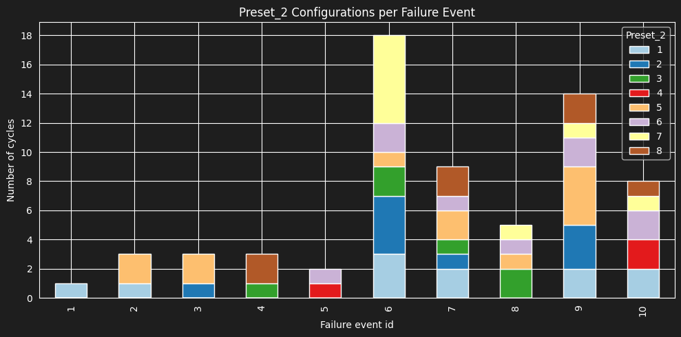

```python
# Create a larger figure
fig, ax = plt.subplots(figsize=(10, 5))

# Stacked barplot for Preset_2 configurations per failure event
df.query('Fail==True').groupby(['Fail_index', 'Preset_2']).size().unstack().plot(
    kind='bar',
    stacked=True,
    colormap='Paired',
    ax=ax
)

# Adjust axes and labels
ax.yaxis.set_major_locator(MaxNLocator(integer=True))
ax.set_ylabel('Number of cycles')
ax.set_xlabel('Failure event id')
ax.set_title('Preset_2 Configurations per Failure Event')

plt.tight_layout()
plt.show()
```

When analyzing **Preset_2**, similar behavior can be found.

**Configuration Diversity During Failures:**

- Multiple Preset_2 values are actively used within individual failure events, possibly indicating operators were trying different configurations to restore normal operation
- This configuration switching behavior is most pronounced in longer failure events (6-10)

**Temporal Pattern in Later Failures:**

- **Preset_2=7 and Preset_2=6** appears consistently across nearly all extended failure periods;
- **Preset_2=5** is used in 60% of all events, but usually for few operation cycles each time.

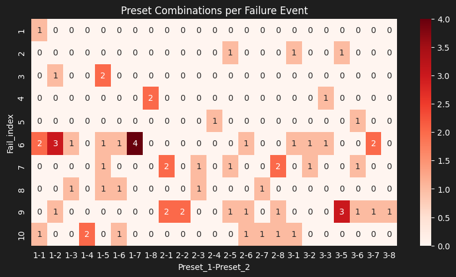

```python
fig, ax = plt.subplots(figsize=(10, 5))

# Create a pivot table showing combinations for each failure event
combo_heatmap = df.query('Fail == True').reset_index().pivot_table(
    values='Cycle',
    index='Fail_index',
    columns=['Preset_1', 'Preset_2'],
    aggfunc='count',
    fill_value=0
)

sns.heatmap(combo_heatmap, annot=True, cmap='Reds', fmt='d')
plt.title('Preset Combinations per Failure Event')
plt.show()
```

When analyzing Preset combinations (Preset_1–Preset_2), similar patterns emerge.

**Configuration During Failures:**

Besides the equipment configuration, it is also important to examine the sensor data behavior during the failure events. This will help reveal how failures manifest in these variables and may allow the identification of different root causes.

```python
def plot_failure_summary_heatmap(df: pd.DataFrame, target_col: str = 'Fail_index', agg_funcs: List[str] = ['mean', 'max', 'median'],
                                figsize: tuple = (16, 10),
                                title: str = "Failure Events Summary - Sensor Statistics") -> None:
    """    Creates a heatmap of failure summary statistics with separate scaling for each variable.
    Args:
        df (pd.DataFrame): DataFrame with failure statistics by event
        target_col (str): Target column name for grouping.
        agg_funcs (List[str]): List of aggregation functions to apply.
        figsize (tuple): Figure size
        title (str): Plot title
    """
    failures_summary = create_stats_summary(df, target_col=target_col, agg_funcs=agg_funcs)

    # Flatten the multi-level columns for easier processing
    df_flat = failures_summary.copy()
    df_flat.columns = [f"{col[0]}_{col[1]}" for col in df_flat.columns]

    # Separate sensor variables from duration
    sensor_cols = [col for col in df_flat.columns if col != f"{target_col}_count"]

    # Create figure with subplots
    fig, axes = plt.subplots(1, 2, figsize=figsize, gridspec_kw={'width_ratios': [4, 1]})

    # Plot 1: Sensor variables heatmap (normalized by column)
    sensor_data = df_flat[sensor_cols]
    sensor_normalized = sensor_data.apply(lambda x: (x - x.min()) / (x.max() - x.min()), axis=0)

    sns.heatmap(sensor_normalized,
                annot=sensor_data.round(1),  # Show actual values
                cmap='RdYlBu_r',
                cbar_kws={'label': 'Normalized Scale (0-1)'},
                ax=axes[0],
                fmt='g')

    axes[0].set_title('Sensor Variables (Each Column Independently Scaled)')
    axes[0].set_ylabel('Failure Event ID')

    # Plot 2: Duration heatmap
    duration_data = df_flat[[f"{target_col}_count"]]
    duration_normalized = (duration_data - duration_data.min()) / (duration_data.max() - duration_data.min())

    sns.heatmap(duration_normalized,
                annot=duration_data,
                cmap='Reds',
                cbar_kws={'label': 'Duration Scale'},
                ax=axes[1],
                fmt='g')

    axes[1].set_title('Duration\n(Cycles)')
    axes[1].set_ylabel('')

    plt.suptitle(title, fontsize=14, y=1.02)
    plt.tight_layout()
    plt.show()
```

| Fail_index | Temperature mean | Temperature max | Temperature std | Pressure mean | Pressure max | Pressure std | VibrationX mean | VibrationX max | VibrationX std | VibrationY mean | VibrationY max | VibrationY std | VibrationZ mean | VibrationZ max | VibrationZ std | Frequency mean | Frequency max | Frequency std | Fail_index count |
| --- | --- | --- | --- | --- | --- | --- | --- | --- | --- | --- | --- | --- | --- | --- | --- | --- | --- | --- | --- |
| 1 | 79.806500 | 79.8065 | NaN | 103.129700 | 103.1297 | NaN | 120.753100 | 120.7531 | NaN | 134.500900 | 134.5009 | NaN | 115.873200 | 115.8732 | NaN | 76.562900 | 76.5629 | NaN | 1 |
| 2 | 89.793400 | 91.6953 | 1.648740 | 90.935467 | 99.2287 | 7.325686 | 91.380267 | 99.8907 | 7.632735 | 114.658167 | 124.9342 | 16.751221 | 99.376567 | 124.9703 | 22.281087 | 90.941567 | 100.2291 | 8.269319 | 3 |
| 3 | 105.646633 | 105.9694 | 0.349649 | 149.796900 | 189.9957 | 39.661919 | 87.096200 | 102.2722 | 16.294318 | 167.350100 | 193.5699 | 22.716728 | 103.069733 | 119.1361 | 14.698026 | 134.016733 | 141.5029 | 6.532205 | 3 |
| 4 | 102.186967 | 115.2786 | 12.534631 | 91.952133 | 114.2295 | 20.071311 | 92.082100 | 114.8593 | 20.293987 | 99.278567 | 116.3420 | 14.779222 | 96.237633 | 115.1043 | 21.083745 | 99.621167 | 113.7843 | 13.998078 | 3 |
| 5 | 106.528700 | 106.5889 | 0.085136 | 109.283950 | 129.4164 | 28.471584 | 110.283350 | 129.7686 | 27.556305 | 99.313450 | 108.0637 | 12.374722 | 153.791500 | 154.2559 | 0.656761 | 100.842550 | 111.2816 | 14.763046 | 2 |
| 6 | 81.412172 | 106.7484 | 20.099746 | 118.305656 | 179.8189 | 40.760012 | 106.975772 | 200.7496 | 42.470806 | 125.920950 | 180.8705 | 39.968608 | 113.727750 | 200.2427 | 42.238767 | 101.289817 | 178.0903 | 34.023272 | 18 |
| 7 | 102.631244 | 150.8803 | 29.619151 | 113.135444 | 160.0359 | 24.468626 | 107.141511 | 130.0623 | 16.759370 | 115.109489 | 150.6206 | 27.501266 | 106.717922 | 129.3918 | 17.165716 | 93.042178 | 115.3036 | 12.030937 | 9 |
| 8 | 97.630860 | 119.6257 | 17.185138 | 103.143800 | 120.9359 | 10.822768 | 97.267500 | 120.8147 | 16.897965 | 115.362860 | 135.5254 | 15.147503 | 96.624160 | 118.7961 | 15.730465 | 114.371660 | 126.2924 | 13.563635 | 5 |
| 9 | 95.510786 | 125.0366 | 16.848968 | 121.211643 | 168.4883 | 22.643369 | 90.278700 | 128.3579 | 17.868311 | 119.466314 | 170.5197 | 25.483081 | 91.870686 | 129.9870 | 16.297279 | 102.017500 | 122.0462 | 9.981906 | 14 |
| 10 | 87.851475 | 127.6708 | 30.563518 | 125.466725 | 160.4336 | 24.599448 | 102.245262 | 151.5853 | 30.794499 | 131.857888 | 169.7738 | 30.037741 | 112.479087 | 148.8385 | 21.180788 | 84.369375 | 110.9193 | 19.967592 | 8 |

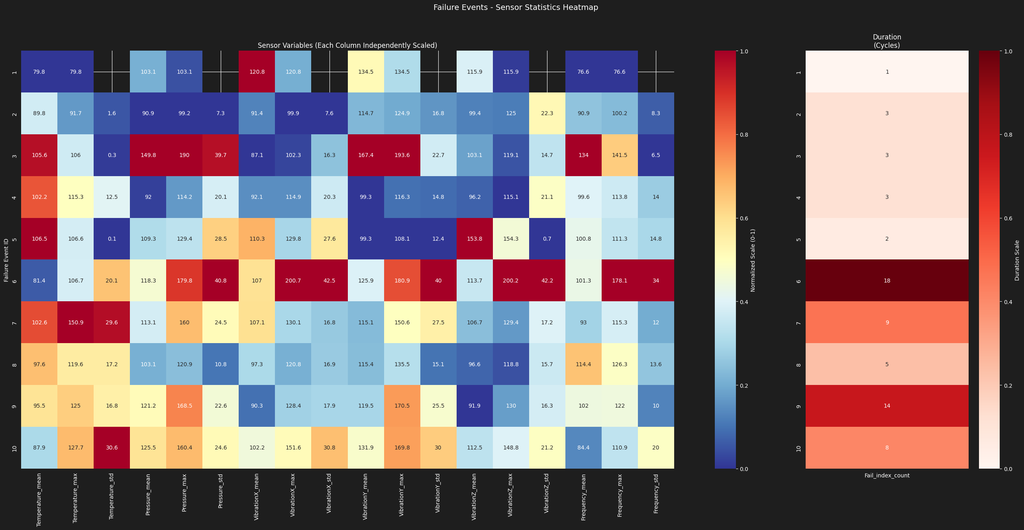

```python
# Create heatmap visualization
failure_summary = create_stats_summary(df.query("Fail == True"), target_col='Fail_index', agg_funcs=['mean', 'max', 'std'])
display(failure_summary)

# Create heatmap visualization
plot_failure_summary_heatmap(df.query("Fail == True"),
                            figsize=(26, 13),
                            agg_funcs=['mean', 'max', 'std'],
                            title="Failure Events - Sensor Statistics Heatmap")
```

Interesting insights can be drawn from the general statistics of sensor data across each failure event.

**Long failures (Events 6-10):** Last 5 or more cycles.

One possible interpretation is that during short failures, the equipment experienced sudden peaks in sensor readings that quickly returned to normal levels. In longer failures, these variables sustained abnormal levels over time, reinforcing the hypothesis of potentially chronic mechanical or process issues. This may also indicate a progressive deterioration in equipment condition over the analyzed period.

Clustering can be useful in this context to validate the above grouping of similar failure events based on sensor behavior.

```python
# Cluster failure events based on sensor characteristics
from sklearn.cluster import KMeans
from sklearn.preprocessing import StandardScaler

# Standardize and cluster
scaler = StandardScaler()
scaled_features = scaler.fit_transform(failure_summary.fillna(0))

kmeans = KMeans(n_clusters=2, random_state=42)
failure_clusters = kmeans.fit_predict(scaled_features)

failure_summary['Cluster'] = failure_clusters
clusters = {}

print("Failure Event Clusters:")
for i, cluster in enumerate(failure_clusters):
    print(f"Event {i+1}: Cluster {cluster}")
    clusters[i+1] = cluster
```

```
Failure Event Clusters:
Event 1: Cluster 0
Event 2: Cluster 0
Event 3: Cluster 1
Event 4: Cluster 0
Event 5: Cluster 0
Event 6: Cluster 1
Event 7: Cluster 1
Event 8: Cluster 0
Event 9: Cluster 1
Event 10: Cluster 1
```

The two clusters align closely with the initial interpretation of short and long failure periods. The only difference is the reassignment of Event 3 and Event 8, now labeled as Cluster 1 and Cluster 0, respectively. This reassignment is reasonable, as Event 3 showed unusually high variability for a short failure, resembling long failures more closely.

To better highlight these differences, it is helpful to recompute a summary of descriptive statistics by cluster.

```python
# Addition of cluster column on the main DataFrame
df['Clusters'] = df['Fail_index'].map(clusters)

create_stats_summary(df.query('Fail == True'),
                     target_col='Clusters',
                     agg_funcs=['mean', 'max', 'std'])
```

| Clusters | Temperature mean | Temperature max | Temperature std | Pressure mean | Pressure max | Pressure std | VibrationX mean | VibrationX max | VibrationX std | VibrationY mean | VibrationY max | VibrationY std | VibrationZ mean | VibrationZ max | VibrationZ std | Frequency mean | Frequency max | Frequency std | Clusters count |
| --- | --- | --- | --- | --- | --- | --- | --- | --- | --- | --- | --- | --- | --- | --- | --- | --- | --- | --- | --- |
| 0.0 | 96.925664 | 119.6257 | 13.057960 | 99.005671 | 129.4164 | 14.808425 | 98.431743 | 129.7686 | 17.315598 | 110.839450 | 135.5254 | 16.270682 | 106.672829 | 154.2559 | 25.402020 | 101.556750 | 126.2924 | 15.880806 | 14 |
| 1.0 | 91.269288 | 150.8803 | 23.427925 | 121.111698 | 189.9957 | 31.440983 | 100.634423 | 200.7496 | 30.488730 | 125.615467 | 193.5699 | 33.154241 | 105.822929 | 200.2427 | 29.354805 | 99.343202 | 178.0903 | 24.628445 | 52 |

The data reveals that Cluster 1, which includes most long-duration failures, exhibits significantly higher values and variability in key variables like **Pressure** and **VibrationY**. Failures in this cluster also show the highest maximum readings across all sensor variables. In contrast, **Frequency** and **VibrationZ** display more consistent behavior across both clusters, suggesting these variables are less discriminative for failure type

### Key Findings of Section 5.4: Caracterizing failure events

**Count of Failure Events:** The equipment had 10 failure events during the period of 800 cycles.

**Failure Durations:**

- **Short failures** (Events 1, 2, 4, 5): Lasted 1–3 cycles, with quick spikes and recoveries
- **Long failures** (Events 6–10): Lasted 5+ cycles, showing sustained issues
- Failures became longer over time, pointing to progressive degradation

**Sensor Behavior:**

- **VibrationY** and **Pressure** had the most noticeable increases during failures
- **Temperature** peaked in Events 3, 4, 5, and 7
- **Variability (STD)** revealed two patterns:
  - **Low STD:** Stable spikes (acute issues)
  - **High STD:** Erratic behavior (unstable failures)

**Failure Clusters:**

- **Cluster 0** (Events 1, 2, 4, 5, 8): Stable failures, low variability
- **Cluster 1** (Events 3, 6, 7, 9, 10): Unstable failures, high variability

**Notable Events:**

- **Event 3:** Short but highly unstable – reclassified correctly due to extreme STD
- **Event 6:** Longer and most unstable – VibrationX STD ~43
- **Event 8:** A long but stable failure, possibly with a different root cause

**Conclusion:** Failures are becoming more frequent and unstable, reinforcing the need for preventive maintenance to avoid critical breakdowns.

## 5.5 Pre-failure event analysis

Besides analyzing equipment behavior during failures, it is also important to understand how the sensor variables behaved in the moments leading up to these events. To achieve this, a good approach is to analyze failure events with buffers of operation cycles preceding each failure onset. This can help identify early indicators or gradual trends that precede equipment failures.

```python
def get_buffer_around_index(df: pd.DataFrame,
                           start_index: int,
                           stop_index: int,
                           buffer_before: int = 5,
                           buffer_after: int = 5,
                           exclude_failure_cycles: bool = False) -> pd.DataFrame:
    """
    Extracts cycles before and after a specific index for analysis of patterns around that point.

    Args:
        df (pd.DataFrame): DataFrame with the data
        start_index (int): The start index around which to create the buffer
        stop_index (int): The stop index around which to create the buffer
        buffer_before (int): Number of cycles before the start index to include
        buffer_after (int): Number of cycles after the stop index to include
        exclude_failure_cycles (bool): If True, excludes cycles that are already in failure

    Returns:
        pd.DataFrame: DataFrame containing only the cycles in the buffer around target index
    """
    buffer_indices = []

    # Calculate the range of the buffer
    start_buffer = start_index - buffer_before
    end_buffer = stop_index + buffer_after-1

    # Ensure we don't go beyond the dataset boundaries
    start_buffer = max(start_buffer, df.index.min())
    end_buffer = min(end_buffer, df.index.max())

    # Add indices to buffer if they exist in the dataset
    for idx in range(start_buffer, end_buffer + 1):
        if idx in df.index:
            # If exclude_failure_cycles=True, only add if not in failure
            if exclude_failure_cycles:
                if not df.loc[idx, 'Fail']:
                    buffer_indices.append(idx)
            else:
                buffer_indices.append(idx)

    # Remove duplicates and sort
    buffer_indices = sorted(list(set(buffer_indices)))

    # Return the subset of DataFrame
    return df.loc[buffer_indices].copy()
```

```python
for event in failure_events['events']:
    print(f"Failure event from cycle {event[0]} to {event[1]}")
    buffer = get_buffer_around_index(df,
                                    start_index=event[0],
                                    stop_index=event[0],
                                    buffer_before=3,
                                    buffer_after=1,
                                    exclude_failure_cycles=False)

    display(buffer)
    display(buffer.select_dtypes(float).std())
    print('\n')
```

```
Failure event from cycle 13 to 14
```

| Cycle | Preset_1 | Preset_2 | Temperature | Pressure | VibrationX | VibrationY | VibrationZ | Frequency | Fail | Fail_index | Clusters |
| --- | --- | --- | --- | --- | --- | --- | --- | --- | --- | --- | --- |
| 10 | 1 | 8 | 42.6192 | 48.3433 | 65.7892 | 49.5248 | 64.9151 | 41.6207 | False | 0 | NaN |
| 11 | 2 | 5 | 59.5014 | 64.4693 | 79.0678 | 65.8915 | 79.4462 | 60.2082 | False | 0 | NaN |
| 12 | 2 | 5 | 80.6625 | 84.2735 | 99.6288 | 83.7019 | 103.1410 | 77.8884 | False | 0 | NaN |
| 13 | 1 | 1 | 79.8065 | 103.1297 | 120.7531 | 134.5009 | 115.8732 | 76.5629 | True | 1 | 0.0 |

```
Temperature    18.202607
Pressure       23.795948
VibrationX     24.064367
VibrationY     36.812452
VibrationZ     22.948455
Frequency      16.989264
Clusters             NaN
dtype: float64
```

```
Failure event from cycle 157 to 160
```

| Cycle | Preset_1 | Preset_2 | Temperature | Pressure | VibrationX | VibrationY | VibrationZ | Frequency | Fail | Fail_index | Clusters |
| --- | --- | --- | --- | --- | --- | --- | --- | --- | --- | --- | --- |
| 154 | 2 | 2 | 79.7849 | 105.1179 | 66.4159 | 59.4661 | 74.2734 | 129.1288 | False | 0 | NaN |
| 155 | 3 | 8 | 79.5837 | 135.1351 | 86.1479 | 70.1276 | 95.0881 | 148.4044 | False | 0 | NaN |
| 156 | 2 | 5 | 159.5474 | 110.2718 | 65.1477 | 64.9867 | 110.3055 | 28.4115 | False | 0 | NaN |
| 157 | 3 | 1 | 91.6953 | 85.3458 | 99.8907 | 95.3284 | 124.9703 | 84.3774 | True | 2 | 0.0 |

```
Temperature    38.350083
Pressure       20.487790
VibrationX     16.704469
VibrationY     15.843971
VibrationZ     21.682003
Frequency      53.344904
Clusters             NaN
dtype: float64
```

```
Failure event from cycle 163 to 166
```

| Cycle | Preset_1 | Preset_2 | Temperature | Pressure | VibrationX | VibrationY | VibrationZ | Frequency | Fail | Fail_index | Clusters |
| --- | --- | --- | --- | --- | --- | --- | --- | --- | --- | --- | --- |
| 160 | 1 | 7 | 40.8615 | 63.6706 | 45.2815 | 48.9689 | 49.9871 | 49.6958 | False | 0 | NaN |
| 161 | 1 | 5 | 59.5663 | 83.7776 | 64.6529 | 69.6966 | 70.0991 | 68.6213 | False | 0 | NaN |
| 162 | 2 | 2 | 92.5016 | 135.2812 | 93.3759 | 98.1428 | 100.3954 | 80.5356 | False | 0 | NaN |
| 163 | 1 | 2 | 105.9694 | 110.6946 | 89.1400 | 153.5759 | 90.2999 | 131.0722 | True | 3 | 1.0 |

```
Temperature    29.825844
Pressure       31.258696
VibrationX     22.461935
VibrationY     45.376284
VibrationZ     22.357825
Frequency      34.793917
Clusters             NaN
dtype: float64
```

```
Failure event from cycle 263 to 266
```

| Cycle | Preset_1 | Preset_2 | Temperature | Pressure | VibrationX | VibrationY | VibrationZ | Frequency | Fail | Fail_index | Clusters |
| --- | --- | --- | --- | --- | --- | --- | --- | --- | --- | --- | --- |
| 260 | 3 | 2 | 46.6000 | 76.5711 | 37.2601 | 69.2705 | 56.1235 | 83.9695 | False | 0 | NaN |
| 261 | 1 | 3 | 93.5530 | 80.1998 | 105.8077 | 39.6004 | 70.2979 | 99.9116 | False | 0 | NaN |
| 262 | 1 | 7 | 255.6078 | 9.4553 | 9.8731 | 74.8139 | 134.3940 | 55.7988 | False | 0 | NaN |
| 263 | 1 | 8 | 90.2957 | 86.3494 | 75.9243 | 116.3420 | 100.1295 | 113.7843 | True | 4 | 0.0 |

```
Temperature    91.923255
Pressure       36.019228
VibrationX     42.232460
VibrationY     31.597227
VibrationZ     34.684294
Frequency      24.895398
Clusters             NaN
dtype: float64
```

```
Failure event from cycle 270 to 272
```

| Cycle | Preset_1 | Preset_2 | Temperature | Pressure | VibrationX | VibrationY | VibrationZ | Frequency | Fail | Fail_index | Clusters |
| --- | --- | --- | --- | --- | --- | --- | --- | --- | --- | --- | --- |
| 267 | 1 | 3 | 70.5914 | 85.3837 | 70.9839 | 64.8894 | 70.0689 | 53.2689 | False | 0 | NaN |
| 268 | 3 | 3 | 101.4256 | 133.4898 | 111.2385 | 95.7359 | 97.5975 | 61.5139 | False | 0 | NaN |
| 269 | 1 | 3 | 99.4922 | 163.8401 | 151.0465 | 97.1699 | 121.1808 | 70.6819 | False | 0 | NaN |
| 270 | 3 | 6 | 106.4685 | 89.1515 | 129.7686 | 90.5632 | 153.3271 | 111.2816 | True | 5 | 0.0 |

```
Temperature    16.204444
Pressure       37.582368
VibrationX     33.993730
VibrationY     15.069680
VibrationZ     35.352420
Frequency      25.732401
Clusters             NaN
dtype: float64
```

```
Failure event from cycle 415 to 433
```

| Cycle | Preset_1 | Preset_2 | Temperature | Pressure | VibrationX | VibrationY | VibrationZ | Frequency | Fail | Fail_index | Clusters |
| --- | --- | --- | --- | --- | --- | --- | --- | --- | --- | --- | --- |
| 412 | 2 | 3 | 57.7674 | 73.6474 | 99.3876 | 54.0781 | 79.8230 | 50.3043 | False | 0 | NaN |
| 413 | 1 | 7 | 78.3564 | 135.3724 | 128.2859 | 93.4023 | 89.2787 | 71.3801 | False | 0 | NaN |
| 414 | 2 | 5 | 80.4735 | 145.6189 | 151.0231 | 104.4367 | 108.0424 | 111.1738 | False | 0 | NaN |
| 415 | 3 | 3 | 78.8621 | 101.4546 | 200.7496 | 50.4818 | 100.0008 | 50.4567 | True | 6 | 1.0 |

```
Temperature    10.769535
Pressure       32.874770
VibrationX     42.833286
VibrationY     27.341015
VibrationZ     12.330841
Frequency      28.660661
Clusters             NaN
dtype: float64
```

```
Failure event from cycle 538 to 547
```

| Cycle | Preset_1 | Preset_2 | Temperature | Pressure | VibrationX | VibrationY | VibrationZ | Frequency | Fail | Fail_index | Clusters |
| --- | --- | --- | --- | --- | --- | --- | --- | --- | --- | --- | --- |
| 535 | 3 | 8 | 49.6836 | 64.5303 | 108.3598 | 105.2326 | 107.7064 | 85.8004 | False | 0 | NaN |
| 536 | 2 | 8 | 51.8942 | 63.6742 | 107.8985 | 104.3127 | 105.7882 | 87.3970 | False | 0 | NaN |
| 537 | 2 | 2 | 51.0660 | 64.9568 | 107.7787 | 105.8909 | 104.1836 | 85.0226 | False | 0 | NaN |
| 538 | 3 | 2 | 74.8169 | 73.4877 | 130.0623 | 75.4030 | 129.3918 | 96.4487 | True | 7 | 1.0 |

```
Temperature    12.002506
Pressure        4.581447
VibrationX     11.027829
VibrationY     14.885278
VibrationZ     11.837455
Frequency       5.280997
Clusters             NaN
dtype: float64
```

```
Failure event from cycle 550 to 555
```

| Cycle | Preset_1 | Preset_2 | Temperature | Pressure | VibrationX | VibrationY | VibrationZ | Frequency | Fail | Fail_index | Clusters |
| --- | --- | --- | --- | --- | --- | --- | --- | --- | --- | --- | --- |
| 547 | 3 | 8 | 119.3465 | 68.1710 | 119.7060 | 75.5152 | 130.2146 | 85.5727 | False | 0 | NaN |
| 548 | 2 | 5 | 78.7495 | 79.9869 | 78.9787 | 79.9463 | 80.7000 | 79.4402 | False | 0 | NaN |
| 549 | 3 | 2 | 101.7001 | 99.7759 | 100.8566 | 100.7341 | 99.1503 | 100.3595 | False | 0 | NaN |
| 550 | 1 | 6 | 71.3373 | 91.6655 | 88.5039 | 135.5254 | 89.9552 | 125.8356 | True | 8 | 0.0 |

```
Temperature    21.924046
Pressure       13.796888
VibrationX     17.582058
VibrationY     27.368557
VibrationZ     21.502186
Frequency      20.648931
Clusters             NaN
dtype: float64
```

```
Failure event from cycle 700 to 714
```

| Cycle | Preset_1 | Preset_2 | Temperature | Pressure | VibrationX | VibrationY | VibrationZ | Frequency | Fail | Fail_index | Clusters |
| --- | --- | --- | --- | --- | --- | --- | --- | --- | --- | --- | --- |
| 697 | 1 | 8 | 91.2214 | 103.9528 | 89.3264 | 124.2531 | 89.1871 | 97.7817 | False | 0 | NaN |
| 698 | 2 | 8 | 53.6886 | 86.6445 | 56.0243 | 49.9237 | 56.3788 | 59.9455 | False | 0 | NaN |
| 699 | 2 | 5 | 84.0818 | 61.2008 | 66.4745 | 134.7877 | 105.3061 | 98.0923 | False | 0 | NaN |
| 700 | 2 | 1 | 89.9807 | 89.4484 | 128.3579 | 91.6058 | 72.8418 | 106.6816 | True | 9 | 1.0 |

```
Temperature    17.646729
Pressure       17.773714
VibrationX     32.048932
VibrationY     38.194302
VibrationZ     21.059870
Frequency      20.864843
Clusters             NaN
dtype: float64
```

```
Failure event from cycle 793 to 801
```

| Cycle | Preset_1 | Preset_2 | Temperature | Pressure | VibrationX | VibrationY | VibrationZ | Frequency | Fail | Fail_index | Clusters |
| --- | --- | --- | --- | --- | --- | --- | --- | --- | --- | --- | --- |
| 790 | 2 | 3 | 95.5450 | 116.4443 | 185.1342 | 43.6493 | 46.0053 | 25.4544 | False | 0 | NaN |
| 791 | 3 | 7 | 39.9099 | 29.7978 | 34.5756 | 44.5606 | 41.5884 | 53.5847 | False | 0 | NaN |
| 792 | 2 | 7 | 84.9908 | 70.5072 | 78.6738 | 96.3826 | 79.1318 | 121.8506 | False | 0 | NaN |
| 793 | 1 | 6 | 127.6708 | 131.5159 | 95.5828 | 132.0539 | 97.2541 | 97.7765 | True | 10 | 1.0 |

```
Temperature    36.279664
Pressure       46.161740
VibrationX     63.228162
VibrationY     43.021355
VibrationZ     26.739341
Frequency      43.307753
Clusters             NaN
dtype: float64
```

This preliminary analysis of the operation cycles preceding failures shows a consistent increase in sensor readings leading up to the failure events. In nearly all 10 recorded failures, at least one variable exhibited a sharp rise or significant variation shortly before the failure occurred.

Therefore, using rolling windows to create new features is a promising approach to predict equipment failures and uncover distinct patterns among different failure types.

```python
def calculate_pre_failure_rolling_features(df: pd.DataFrame,
                                         failure_events: dict,
                                         buffer_size: int = 4,
                                         windows: List[int] = [3],
                                         sensor_cols: List[str] = None) -> pd.DataFrame:
    """
    Calculate rolling window features for cycles preceding each failure event.
    Uses existing get_buffer_around_index function.

    Args:
        df (pd.DataFrame): Main DataFrame with sensor data
        failure_events (dict): Dictionary with failure events (from find_failure_transitions)
        buffer_size (int): Number of cycles before failure to analyze
        windows (List[int]): Window sizes for rolling calculations
        sensor_cols (List[str]): Sensor columns to analyze. If None, uses float columns

    Returns:
        pd.DataFrame: DataFrame with pre-failure rolling features for each event
    """
    if sensor_cols is None:
        sensor_cols = df.select_dtypes(include=['float64']).columns.tolist()

    pre_failure_features = []

    # Iterate through each failure event
    for event_idx, (start_cycle, _) in enumerate(failure_events['events']):
        # Use existing function to get buffer
        buffer_data = get_buffer_around_index(
            df=df,
            start_index=start_cycle,
            stop_index=start_cycle,  # Only need start point
            buffer_before=buffer_size,
            buffer_after=1,  # buffer = 1 to consider failure start point
            exclude_failure_cycles=False  # Exclude cycles already in failure
        )

        if len(buffer_data) > 0:
            # Calculate rolling features for this buffer
            event_features = {'Fail_index': event_idx + 1}

            for window in windows:
                for col in sensor_cols:
                    if col in buffer_data.columns:
                        # Rolling statistics, get value from the beginning of the failure
                        rolling_mean = buffer_data[col].rolling(window=window, min_periods=1).mean().iloc[-1]
                        rolling_std = buffer_data[col].rolling(window=window, min_periods=1).std().iloc[-1]

                        # Calculate percent change
                        # If buffer is smaller than window, set pct_change to 0
                        if len(buffer_data) > window:
                            pct_change = buffer_data[col].pct_change(periods=window).iloc[-1]
                        else:
                            pct_change = 0

                        # Store features
                        event_features[f'{col}_rolling_mean_{window}'] = rolling_mean
                        event_features[f'{col}_rolling_std_{window}'] = rolling_std
                        event_features[f'{col}_pct_change_{window}'] = pct_change

            pre_failure_features.append(event_features)

    return pd.DataFrame(pre_failure_features)

# Usage:
pre_failure_df = calculate_pre_failure_rolling_features(
    df=df,
    failure_events=failure_events,
    buffer_size=2,
    windows=[3],
    sensor_cols=['Temperature', 'Pressure', 'VibrationX', 'VibrationY', 'VibrationZ', 'Frequency']
)

print(f"Pre-failure features shape: {pre_failure_df.shape}")
display(pre_failure_df)
```

```
Pre-failure features shape: (10, 19)
```

|  | Fail_index | Temperature_rolling_mean_3 | Temperature_rolling_std_3 | Temperature_pct_change_3 | Pressure_rolling_mean_3 | Pressure_rolling_std_3 | Pressure_pct_change_3 | VibrationX_rolling_mean_3 | VibrationX_rolling_std_3 | VibrationX_pct_change_3 | VibrationY_rolling_mean_3 | VibrationY_rolling_std_3 | VibrationY_pct_change_3 | VibrationZ_rolling_mean_3 | VibrationZ_rolling_std_3 | VibrationZ_pct_change_3 | Frequency_rolling_mean_3 | Frequency_rolling_std_3 | Frequency_pct_change_3 |
| --- | --- | --- | --- | --- | --- | --- | --- | --- | --- | --- | --- | --- | --- | --- | --- | --- | --- | --- | --- |
| 0 | 1 | 73.323467 | 11.977910 | 0 | 83.957500 | 19.332137 | 0 | 99.816567 | 20.843284 | 0 | 94.698100 | 35.601963 | 0 | 99.486800 | 18.486386 | 0 | 71.553167 | 9.847357 | 0 |
| 1 | 2 | 110.275467 | 43.098321 | 0 | 110.250900 | 24.894657 | 0 | 83.728767 | 17.497376 | 0 | 76.814233 | 16.238472 | 0 | 110.121300 | 14.941952 | 0 | 87.064433 | 60.041562 | 0 |
| 2 | 3 | 86.012433 | 23.872450 | 0 | 109.917800 | 25.760586 | 0 | 82.389600 | 15.505760 | 0 | 107.138433 | 42.657066 | 0 | 86.931467 | 15.426477 | 0 | 93.409700 | 33.156230 | 0 |
| 3 | 4 | 146.485500 | 94.516717 | 0 | 58.668167 | 42.730365 | 0 | 63.868367 | 49.090437 | 0 | 76.918767 | 38.414075 | 0 | 101.607133 | 32.073588 | 0 | 89.831567 | 30.278455 | 0 |
| 4 | 5 | 102.462100 | 3.601797 | 0 | 128.827133 | 37.561977 | 0 | 130.684533 | 19.919800 | 0 | 94.489667 | 3.475190 | 0 | 124.035133 | 27.974229 | 0 | 81.159133 | 26.486512 | 0 |
| 5 | 6 | 79.230667 | 1.105626 | 0 | 127.481967 | 23.115267 | 0 | 160.019533 | 37.060070 | 0 | 82.773600 | 28.504557 | 0 | 99.107300 | 9.413706 | 0 | 77.670200 | 30.843404 | 0 |
| 6 | 7 | 59.259033 | 13.479870 | 0 | 67.372900 | 5.334262 | 0 | 115.246500 | 12.830999 | 0 | 95.202200 | 17.164758 | 0 | 113.121200 | 14.113575 | 0 | 89.622767 | 6.029467 | 0 |
| 7 | 8 | 83.928967 | 15.830195 | 0 | 90.476100 | 9.947971 | 0 | 89.446400 | 10.969360 | 0 | 105.401933 | 28.082033 | 0 | 89.935167 | 9.225166 | 0 | 101.878433 | 23.234966 | 0 |
| 8 | 9 | 75.917033 | 19.475027 | 0 | 79.097900 | 15.562619 | 0 | 83.618900 | 39.095847 | 0 | 92.105733 | 42.434209 | 0 | 78.175567 | 24.895923 | 0 | 88.239800 | 24.877089 | 0 |
| 9 | 10 | 84.190500 | 43.885923 | 0 | 77.273633 | 51.195522 | 0 | 69.610733 | 31.497206 | 0 | 90.999033 | 43.994391 | 0 | 72.658100 | 28.391885 | 0 | 91.070600 | 34.623476 | 0 |

```python
# Standardize and cluster
scaler = StandardScaler()
scaled_features = scaler.fit_transform(pre_failure_df.fillna(0))

kmeans = KMeans(n_clusters=2, random_state=42)
pre_failure_clusters = kmeans.fit_predict(scaled_features)

pre_failure_df['Cluster'] = pre_failure_clusters
clusters = {}

print("Failure Event Clusters:")
for i, cluster in enumerate(pre_failure_clusters):
    print(f"Event {i+1}: Cluster {cluster}")
    clusters[i+1] = cluster
```

```
Failure Event Clusters:
Event 1: Cluster 1
Event 2: Cluster 1
Event 3: Cluster 1
Event 4: Cluster 0
Event 5: Cluster 1
Event 6: Cluster 1
Event 7: Cluster 1
Event 8: Cluster 1
Event 9: Cluster 1
Event 10: Cluster 0
```

```python
# Dataframe with pre-failure rolling features and clusters
display(pre_failure_df)
```

|  | Fail_index | Temperature_rolling_mean_3 | Temperature_rolling_std_3 | Temperature_pct_change_3 | Pressure_rolling_mean_3 | Pressure_rolling_std_3 | Pressure_pct_change_3 | VibrationX_rolling_mean_3 | VibrationX_rolling_std_3 | VibrationX_pct_change_3 | VibrationY_rolling_mean_3 | VibrationY_rolling_std_3 | VibrationY_pct_change_3 | VibrationZ_rolling_mean_3 | VibrationZ_rolling_std_3 | VibrationZ_pct_change_3 | Frequency_rolling_mean_3 | Frequency_rolling_std_3 | Frequency_pct_change_3 | Cluster |
| --- | --- | --- | --- | --- | --- | --- | --- | --- | --- | --- | --- | --- | --- | --- | --- | --- | --- | --- | --- | --- |
| 0 | 1 | 73.323467 | 11.977910 | 0 | 83.957500 | 19.332137 | 0 | 99.816567 | 20.843284 | 0 | 94.698100 | 35.601963 | 0 | 99.486800 | 18.486386 | 0 | 71.553167 | 9.847357 | 0 | 1 |
| 1 | 2 | 110.275467 | 43.098321 | 0 | 110.250900 | 24.894657 | 0 | 83.728767 | 17.497376 | 0 | 76.814233 | 16.238472 | 0 | 110.121300 | 14.941952 | 0 | 87.064433 | 60.041562 | 0 | 1 |
| 2 | 3 | 86.012433 | 23.872450 | 0 | 109.917800 | 25.760586 | 0 | 82.389600 | 15.505760 | 0 | 107.138433 | 42.657066 | 0 | 86.931467 | 15.426477 | 0 | 93.409700 | 33.156230 | 0 | 1 |
| 3 | 4 | 146.485500 | 94.516717 | 0 | 58.668167 | 42.730365 | 0 | 63.868367 | 49.090437 | 0 | 76.918767 | 38.414075 | 0 | 101.607133 | 32.073588 | 0 | 89.831567 | 30.278455 | 0 | 0 |
| 4 | 5 | 102.462100 | 3.601797 | 0 | 128.827133 | 37.561977 | 0 | 130.684533 | 19.919800 | 0 | 94.489667 | 3.475190 | 0 | 124.035133 | 27.974229 | 0 | 81.159133 | 26.486512 | 0 | 1 |
| 5 | 6 | 79.230667 | 1.105626 | 0 | 127.481967 | 23.115267 | 0 | 160.019533 | 37.060070 | 0 | 82.773600 | 28.504557 | 0 | 99.107300 | 9.413706 | 0 | 77.670200 | 30.843404 | 0 | 1 |
| 6 | 7 | 59.259033 | 13.479870 | 0 | 67.372900 | 5.334262 | 0 | 115.246500 | 12.830999 | 0 | 95.202200 | 17.164758 | 0 | 113.121200 | 14.113575 | 0 | 89.622767 | 6.029467 | 0 | 1 |
| 7 | 8 | 83.928967 | 15.830195 | 0 | 90.476100 | 9.947971 | 0 | 89.446400 | 10.969360 | 0 | 105.401933 | 28.082033 | 0 | 89.935167 | 9.225166 | 0 | 101.878433 | 23.234966 | 0 | 1 |
| 8 | 9 | 75.917033 | 19.475027 | 0 | 79.097900 | 15.562619 | 0 | 83.618900 | 39.095847 | 0 | 92.105733 | 42.434209 | 0 | 78.175567 | 24.895923 | 0 | 88.239800 | 24.877089 | 0 | 1 |
| 9 | 10 | 84.190500 | 43.885923 | 0 | 77.273633 | 51.195522 | 0 | 69.610733 | 31.497206 | 0 | 90.999033 | 43.994391 | 0 | 72.658100 | 28.391885 | 0 | 91.070600 | 34.623476 | 0 | 0 |

This suggests the presence of two distinct pre-failure behavior patterns, which may reflect different failure mechanisms or root causes across events.

```python
# Statistics summary for pre-failure features by cluster
create_stats_summary(pre_failure_df, target_col='Cluster', agg_funcs=['mean'])
```

| Cluster | Temperature_rolling_mean_3 mean | Temperature_rolling_std_3 mean | Pressure_rolling_mean_3 mean | Pressure_rolling_std_3 mean | VibrationX_rolling_mean_3 mean | VibrationX_rolling_std_3 mean | VibrationY_rolling_mean_3 mean | VibrationY_rolling_std_3 mean | VibrationZ_rolling_mean_3 mean | VibrationZ_rolling_std_3 mean | Frequency_rolling_mean_3 mean | Frequency_rolling_std_3 mean | Cluster count |
| --- | --- | --- | --- | --- | --- | --- | --- | --- | --- | --- | --- | --- | --- |
| 0 | 115.338000 | 69.20132 | 67.970900 | 46.962943 | 66.73955 | 40.293822 | 83.958900 | 41.204233 | 87.132617 | 30.232737 | 90.451083 | 32.450966 | 2 |
| 1 | 83.801146 | 16.55515 | 99.672775 | 20.188684 | 105.61885 | 21.715312 | 93.577988 | 26.769781 | 100.114242 | 16.809677 | 86.324704 | 26.814573 | 8 |

Understanding these distinct pre-failure signatures could allow monitoring approaches:

- **Cluster 0 (Temperature-Driven Failures)**: Characterized by sudden temperature spikes with high variability before failure. These events require immediate alerts when temperature volatility exceeds normal ranges.
- **Cluster 1 (Pressure/Vibration-Driven Failures)**: Marked by gradual buildup in pressure and vibration levels with sustained elevation. These failures could benefit from **trend-based monitoring** that tracks progressive deterioration over multiple cycles.

The same logic could be used to analyze patterns on equipment setups. Below the analyzis main goal is to identify the combinations of **Preset_1** and **Preset_2** that are most frequent in operation cycles before failures.

```python
# Create a DataFrame to hold pre-failure data
presets_pre_failure = pd.DataFrame()

# Loop through each failure event to extract pre-failure data
for event in failure_events['events']:
    start_cycle = event[0]
    print(f"Failure event from cycle {start_cycle} to {event[1]}")

    # Get buffer of two operations cycles before beggining of failures
    buffer_data = get_buffer_around_index(
                df=df,
                start_index=start_cycle,
                stop_index=start_cycle,  # Only need start point
                buffer_before=2,
                buffer_after=1,  # buffer = 1 to consider failure start point
                exclude_failure_cycles=True  # Exclude cycles already in failure
            )

    # Filter columns to keep only integer types
    buffer_data = buffer_data.select_dtypes(int)

    # Add failure index to identify the failure event
    buffer_data['Fail_index'] = failure_events['events'].index(event) + 1  # Assigning failure index

    # Concatenate the buffer data to the main DataFrame
    presets_pre_failure = pd.concat([presets_pre_failure, buffer_data])

display(presets_pre_failure)
```

```
Failure event from cycle 13 to 14
Failure event from cycle 157 to 160
Failure event from cycle 163 to 166
Failure event from cycle 263 to 266
Failure event from cycle 270 to 272
Failure event from cycle 415 to 433
Failure event from cycle 538 to 547
Failure event from cycle 550 to 555
Failure event from cycle 700 to 714
Failure event from cycle 793 to 801
```

| Cycle | Preset_1 | Preset_2 | Fail_index |
| --- | --- | --- | --- |
| 11 | 2 | 5 | 1 |
| 12 | 2 | 5 | 1 |
| 155 | 3 | 8 | 2 |
| 156 | 2 | 5 | 2 |
| 161 | 1 | 5 | 3 |
| 162 | 2 | 2 | 3 |
| 261 | 1 | 3 | 4 |
| 262 | 1 | 7 | 4 |
| 268 | 3 | 3 | 5 |
| 269 | 1 | 3 | 5 |
| 413 | 1 | 7 | 6 |
| 414 | 2 | 5 | 6 |
| 536 | 2 | 8 | 7 |
| 537 | 2 | 2 | 7 |
| 548 | 2 | 5 | 8 |
| 549 | 3 | 2 | 8 |
| 698 | 2 | 8 | 9 |
| 699 | 2 | 5 | 9 |
| 791 | 3 | 7 | 10 |
| 792 | 2 | 7 | 10 |

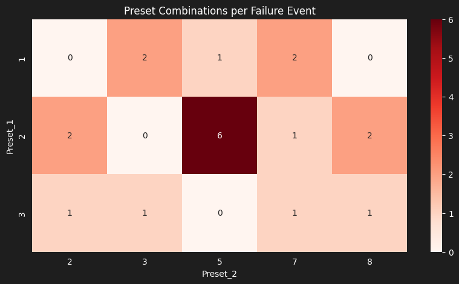

```python
# Heatmap plotting preset combinations on operation cycles before failure events
fig, ax = plt.subplots(figsize=(10, 5))

combo_heatmap = presets_pre_failure.groupby(['Preset_1','Preset_2']).size().unstack(fill_value=0)

sns.heatmap(combo_heatmap, annot=True, cmap='Reds', fmt='d')
plt.title('Preset Combinations per Failure Event')
plt.show()
```

- Preset_2=5 appears to be a high-risk precursor. It's the most common setting used in the cycles immediately before failures occur;
- When Preset_1=2 is used (especially with Preset_2=5), it strongly correlates with impending failure

### Key Findings of Section 5.5: Pre-failure event analysis

**Early Warning Signals:**

- Nearly all 10 failures showed sensor changes 2-3 cycles before failing
- Two distinct failure patterns were identified

- Sudden temperature spikes before failure
- **Monitor**: Set alerts for temperature volatility

- Gradual pressure and vibration increases
- **Monitor**: Track trends over multiple cycles

# 6 EDA Conclusion

This exploratory data analysis revealed key insights into equipment failures and operational patterns:

## Key Findings Summary

### Sensor Behavior During Failures

- **Primary Indicators:** `Pressure` (+40 units) and `VibrationY` (+54 units) show the strongest failure signals
- **Clear Separation:** Minimal overlap between normal and failure distributions across all sensors
- **Early Warning:** Sensor changes detectable 2-3 cycles before failures

### Equipment Configuration Risk

- **High-Risk Combinations:**
  - `Preset_1=1, Preset_2=5`: 16% failure rate (double the baseline)
  - `Preset_1=2, Preset_2=5`: Most common before failures
- **Safe Configuration:** `Preset_1=3, Preset_2=4` shows 0% failure rate

# 7. Model exploration

With the main patterns and risk factors identified through EDA, the following section explores predictive modeling approaches to forecast equipment failures based on the processed dataset.

```python
# Read the processed data
from src.config import ApplicationConfig
df = pd.read_csv(ApplicationConfig().processed_data_path, index_col='Cycle')
```

## 7.1 One-Hot Encoding

To ensure that the categorical setup parameters are properly represented for machine learning algorithms, one-hot encoding need to be applied `Preset_1` and `Preset_2` columns.

```python
def map_bool_to_int(df: pd.DataFrame, column: str) -> pd.DataFrame:
    """
    Maps boolean values in the specified column to integers: True → 1, False → 0.

    Args:
        df (pd.DataFrame): The input DataFrame.
        column (str): The name of the column to convert.

    Returns:
        pd.DataFrame: Updated DataFrame with the column converted to integers.
    """
    df[column] = df[column].astype(int)
    return df

def one_hot_encode_column(df: pd.DataFrame, column: str, prefix: str = None, drop_original: bool = True) -> pd.DataFrame:
    """
    Applies one-hot encoding to a single column in the DataFrame.

    Args:
        df (pd.DataFrame): The input DataFrame.
        column (str): The name of the column to encode.
        prefix (str, optional): Prefix for new columns. Defaults to column name.
        drop_original (bool): Whether to drop the original column. Defaults to True.

    Returns:
        pd.DataFrame: DataFrame with one-hot encoded columns.
    """
    if prefix is None:
        prefix = column

    dummies = pd.get_dummies(df[column], prefix=prefix)

    df_encoded = pd.concat([df, dummies], axis=1)

    if drop_original:
        df_encoded = df_encoded.drop(columns=[column])

    return df_encoded

def encode_dataset(df: pd.DataFrame,
                        one_hot_columns: List[str] = None) -> pd.DataFrame:
    """
    Encodes the DataFrame by mapping boolean columns to integers and applying one-hot encoding to specified columns.

    Args:
        df (pd.DataFrame): The input DataFrame.
        bool_columns (List[str], optional): List of boolean columns to map to integers. Defaults to None.
        one_hot_columns (List[str], optional): List of columns to apply one-hot encoding. Defaults to None.

    Returns:
        pd.DataFrame: Encoded DataFrame.
    """
    if one_hot_columns is not None:
        for col in one_hot_columns:
            df = one_hot_encode_column(df, col)

    for col in df.select_dtypes(include=['bool']).columns:
        df = map_bool_to_int(df, col)

    return df
```

```python
df_encoded = encode_dataset(df, one_hot_columns=['Preset_1', 'Preset_2'])
display(df_encoded)
```

| Cycle | Temperature | Pressure | VibrationX | VibrationY | VibrationZ | Frequency | Fail | Preset_1_1 | Preset_1_2 | Preset_1_3 | Preset_2_1 | Preset_2_2 | Preset_2_3 | Preset_2_4 | Preset_2_5 | Preset_2_6 | Preset_2_7 | Preset_2_8 |
| --- | --- | --- | --- | --- | --- | --- | --- | --- | --- | --- | --- | --- | --- | --- | --- | --- | --- | --- |
| 1 | 44.2352 | 47.6573 | 46.4418 | 64.8203 | 66.4545 | 44.4832 | 0 | 0 | 0 | 1 | 0 | 0 | 0 | 0 | 0 | 1 | 0 | 0 |
| 2 | 60.8072 | 63.1721 | 62.0060 | 80.7144 | 81.2464 | 60.2287 | 0 | 0 | 1 | 0 | 0 | 0 | 0 | 1 | 0 | 0 | 0 | 0 |
| 3 | 79.0275 | 83.0322 | 82.6421 | 98.2544 | 98.7852 | 80.9935 | 0 | 0 | 1 | 0 | 1 | 0 | 0 | 0 | 0 | 0 | 0 | 0 |
| 4 | 79.7162 | 100.5086 | 122.3623 | 121.3634 | 118.6525 | 80.3156 | 0 | 0 | 1 | 0 | 0 | 0 | 1 | 0 | 0 | 0 | 0 | 0 |
| 5 | 39.9891 | 51.7648 | 42.5143 | 61.0379 | 50.7165 | 64.2452 | 0 | 0 | 1 | 0 | 0 | 0 | 0 | 0 | 1 | 0 | 0 | 0 |
| ... | ... | ... | ... | ... | ... | ... | ... | ... | ... | ... | ... | ... | ... | ... | ... | ... | ... | ... |
| 796 | 50.4695 | 98.2354 | 151.5853 | 99.3414 | 148.8385 | 49.8414 | 1 | 0 | 1 | 0 | 0 | 0 | 0 | 0 | 0 | 1 | 0 | 0 |
| 797 | 49.9853 | 160.4336 | 110.9530 | 160.7772 | 109.9176 | 110.9193 | 1 | 1 | 0 | 0 | 0 | 0 | 0 | 1 | 0 | 0 | 0 | 0 |
| 798 | 79.7773 | 110.5354 | 61.3350 | 149.5778 | 129.4638 | 70.8534 | 1 | 1 | 0 | 0 | 0 | 0 | 0 | 1 | 0 | 0 | 0 | 0 |
| 799 | 79.3603 | 159.9854 | 61.7629 | 169.7738 | 130.2134 | 80.1135 | 1 | 0 | 1 | 0 | 0 | 0 | 0 | 0 | 0 | 0 | 0 | 1 |
| 800 | 80.8540 | 110.5437 | 121.0322 | 131.7195 | 90.3312 | 71.2617 | 1 | 0 | 0 | 1 | 1 | 0 | 0 | 0 | 0 | 0 | 0 | 0 |

800 rows × 18 columns

## 7.2 Baseline model

To compare future Machine Learning models results, a Random Forest model will be used as a baseline. The model uses only one-hot encoding and normalization on the existing variables.

### 7.2.1 Train and test set creation

Before normalization, the dataset will be split in two separate groups for training and testing.

```python
from sklearn.model_selection import train_test_split

def create_train_test_split(df: pd.DataFrame, target_col='Fail', test_size=0.2, random_state=42, stratify=True):
    """
    Splits the encoded DataFrame into train and test sets.

    Args:
        df (pd.DataFrame): The DataFrame.
        target_col (str): Name of the target column.
        test_size (float): Proportion of test set.
        random_state (int): Random seed.
        stratify (bool): Whether to stratify by target.

    Returns:
        X_train, X_test, y_train, y_test (pd.DataFrame, pd.DataFrame, pd.Series, pd.Series)
    """

    X = df.drop(columns=[target_col])
    y = df[target_col]
    stratify_y = y if stratify else None

    X_train, X_test, y_train, y_test = train_test_split(
        X, y, test_size=test_size, random_state=random_state, stratify=stratify_y
    )
    return X_train, X_test, y_train, y_test

# Usage:
X_train, X_test, y_train, y_test = create_train_test_split(df_encoded)
```

### 7.2.2 Normalization

To ensure that all features contribute equally to the model and to improve convergence during training, normalization is applied to the dataset.

```python
from sklearn.preprocessing import StandardScaler

def scale_features(X_train, X_test, scaler=None):
    """
    Scales train and test features using the provided scaler (StandardScaler by default).

    Args:
        X_train (np.ndarray or pd.DataFrame): Training features.
        X_test (np.ndarray or pd.DataFrame): Test features.
        scaler: Scaler instance (if None, uses StandardScaler).

    Returns:
        X_train_scaled, X_test_scaled
    """
    if scaler is None:
        scaler = StandardScaler()
    X_train_scaled = scaler.fit_transform(X_train)
    X_test_scaled = scaler.transform(X_test)
    return X_train_scaled, X_test_scaled

# Example usage:
X_train_scaled, X_test_scaled = scale_features(X_train, X_test)
```

## 7.2.3 First prediciton

```python
from sklearn.ensemble import RandomForestClassifier
from sklearn.metrics import classification_report

rf = RandomForestClassifier(class_weight='balanced', random_state=42)

rf.fit(X_train_scaled, y_train)
predictions = rf.predict(X_test_scaled)

print(classification_report(y_test, predictions))
```

```
              precision    recall  f1-score   support

           0       0.96      0.99      0.97       147
           1       0.78      0.54      0.64        13

    accuracy                           0.95       160
   macro avg       0.87      0.76      0.80       160
weighted avg       0.95      0.95      0.95       160
```

The model performs had high precision (0.96) and recall (0.99) on normal operation cycles. But for failure events (class 1), precision and recall drops are not good.

Thus, even with overall accuracy is high (0.95), the model's limited ability to identify failures shows necessary improvements such as creation of new features on the dataset.

## 7.3 Feature Engineering

To improve the model's ability to identify failures, **feature engineering** is essential. This process involves creating new variables that better capture the patterns and early warning signals present in the data.

Based on the previously findings of this study, valuable new features could include:

- **Rolling window statistics** to capture trends and sudden changes in sensor readings before failures.
- **Threshold-based alert features** to flag extreme sensor values.
- **Risk-based setup combinations** to highlight high-risk equipment configurations.

### 7.3.1 Rolling window features

Rolling window features are designed to capture short-term trends and sudden changes in sensor data that often precede equipment failures.

- **Window size impact:** Using 3- and 5-cycle windows allows the model to estimate both immediate and slightly longer-term changes, improving its ability to identify early warning patterns

```python
def add_sensor_rolling_features(df: pd.DataFrame, sensor_cols: List[str], windows: List[int] = [3, 5]):
    """
    Adds rolling window features (mean, std, percent change) for specified sensor columns and window sizes.

    For each column in sensor_cols and each window in windows, the following features are added:
        - Rolling mean: {col}_rolling_mean_{window}
        - Rolling std: {col}_rolling_std_{window}
        - Percent change over window: {col}_pct_change_{window}

    Args:
        df (pd.DataFrame): The input DataFrame.
        sensor_cols (List[str]): List of sensor column names to compute features for.
        windows (List[int], optional): List of window sizes for rolling calculations. Defaults to [3, 5].

    Returns:
        pd.DataFrame: DataFrame with new rolling window features added.
    """
    # Create a copy of the DataFrame to avoid modifying the original
    window_features = df.copy()

    for window in windows:
        for col in sensor_cols:
            # Rolling mean
            window_features[f'{col}_rolling_mean_{window}'] = window_features[col].rolling(window).mean()
            # Rolling standard deviation
            window_features[f'{col}_rolling_std_{window}'] = window_features[col].rolling(window).std()
            # Percent change over the window
            window_features[f'{col}_pct_change_{window}'] = window_features[col].pct_change(periods=window)

    return window_features
```

```python
# Adding rolling features to the DataFrame
window_features = add_sensor_rolling_features(df_encoded, ApplicationConfig().sensor_columns, windows=[3,5])
window_features.fillna(0, inplace=True)
```

```python
# New train-test split with rolling features
X_train, X_test, y_train, y_test = create_train_test_split(window_features)
X_train_scaled, X_test_scaled = scale_features(X_train, X_test)

# RF model with rolling features and hyperparameters
rf = RandomForestClassifier(class_weight='balanced', n_estimators=160,
                            random_state=42)

rf.fit(X_train_scaled, y_train)
pred = rf.predict(X_test_scaled)
print(f"\nRandom Forest Results:")
print(classification_report(y_test, pred))
```

```
Random Forest Results:
              precision    recall  f1-score   support

           0       0.97      1.00      0.99       147
           1       1.00      0.69      0.82        13

    accuracy                           0.97       160
   macro avg       0.99      0.85      0.90       160
weighted avg       0.98      0.97      0.97       160
```

- **Precision 100% = 0 False Positives, no false alarms;**
- **Recall still needs improvement, failures were not well predicted.**

Although rolling window features (using 3 and 5 operation cycles) help capture trends of increase and sudden variabilities before failures, the model still struggles to identify actual failure events.

### 7.3.2 Sensor threshold features

As discussed earlier, failures are strongly associated with higher values in sensor variables. To capture this relationship, **threshold-based alert features** are created for each sensor.

These features indicate operation cycles where sensor readings exceed critical percentiles.

```python
def add_sensor_threshold_features(df: pd.DataFrame, sensor_cols: List[str]) -> pd.DataFrame:
    """Add threshold-based alert features for sensors."""
    # Create a copy of the DataFrame to avoid modifying the original
    df_threshold = df.copy()

    for col in sensor_cols:
        # High alert: above 90th percentile
        threshold_high = df[col].quantile(0.9)
        df_threshold[f'{col}_high_alert'] = (df_threshold[col] > threshold_high).astype(int)

        # Extreme alert: above 95th percentile
        threshold_extreme = df[col].quantile(0.95)
        df_threshold[f'{col}_extreme_alert'] = (df_threshold[col] > threshold_extreme).astype(int)

    return df_threshold
```

```python
# Adding threshold features to the DataFrame
df_threshold = add_sensor_threshold_features(window_features, ApplicationConfig().sensor_columns)
```

```python
# New train-test split with threshold features
X_train, X_test, y_train, y_test = create_train_test_split(df_threshold)
X_train_scaled, X_test_scaled = scale_features(X_train, X_test)

# RF model with threshold features and hyperparameters
rf = RandomForestClassifier(class_weight='balanced', n_estimators=180, min_samples_leaf=2,
                            random_state=42)

rf.fit(X_train_scaled, y_train)
pred = rf.predict(X_test_scaled)
print(f"\nRandom Forest Results:")
print(classification_report(y_test, pred))
```

```
Random Forest Results:
              precision    recall  f1-score   support

           0       0.99      1.00      0.99       147
           1       1.00      0.85      0.92        13

    accuracy                           0.99       160
   macro avg       0.99      0.92      0.95       160
weighted avg       0.99      0.99      0.99       160
```

Adding sensor threshold features led to a significant improvement in recall for failure events (class 1), now at 0.85, while maintaining perfect precision (1.00) for failures and almost perfect for normal cycles.

The model is now much better at detecting actual failures, with very few false negatives and almost no false positives.

### 7.3.3 Setup combinations feature

Another important finding in this notebook is that specific combinations of **Preset_1** and **Preset_2** are associated with significantly higher failure rates and can be considered high-risk setups.

To capture this, a new set of binary features is created to flag these risky configurations. These features help the model identify operation cycles with a historically higher likelihood of failure due to their configuration.

```python
def add_high_risk_preset_features(df: pd.DataFrame) -> pd.DataFrame:
    """Add binary features for high-risk preset combinations."""

    # High-risk combinations during failures
    df['high_risk_combo_1_5'] = ((df['Preset_1'] == 1) & (df['Preset_2'] == 5)).astype(int)
    df['high_risk_combo_3_5'] = ((df['Preset_1'] == 3) & (df['Preset_2'] == 5)).astype(int)
    df['high_risk_combo_1_2'] = ((df['Preset_1'] == 1) & (df['Preset_2'] == 2)).astype(int)

    return df
```

```python
df = add_high_risk_preset_features(df)
df_encoded = encode_dataset(df, one_hot_columns=ApplicationConfig().categorical_columns)
window_features = add_sensor_rolling_features(df_encoded, ApplicationConfig().sensor_columns, windows=[3,5])
window_features.fillna(0, inplace=True)
df_threshold = add_sensor_threshold_features(window_features, ApplicationConfig().sensor_columns)
```

```python
# New train-test split with rolling features and high-risk preset features
X_train, X_test, y_train, y_test = create_train_test_split(df_threshold)
X_train_scaled, X_test_scaled = scale_features(X_train, X_test)

# RF model with rolling features and hyperparameters
rf = RandomForestClassifier(class_weight='balanced', n_estimators=200, min_samples_leaf=4,
                            random_state=42)

rf.fit(X_train_scaled, y_train)
pred = rf.predict(X_test_scaled)
print(f"\nRandom Forest Results:")
print(classification_report(y_test, pred))
```

```
Random Forest Results:
              precision    recall  f1-score   support

           0       0.99      1.00      0.99       147
           1       1.00      0.85      0.92        13

    accuracy                           0.99       160
   macro avg       0.99      0.92      0.95       160
weighted avg       0.99      0.99      0.99       160
```

Apparently, the flag of risky configurations was not sucessful on helping separe normal cycles from failures.Given the small dataset and low representation of fail events, further improvements can be limited by the small number of failure samples.

- **To address this, SMOTE (Synthetic Minority Over-sampling Technique) is used to generate synthetic failure samples and balance the dataset.** This helps the model generalize better and improves recall for rare failure events.

## 7.4 Oversampling with SMOTE

```python
from imblearn.pipeline import Pipeline
from imblearn.over_sampling import SMOTE
from sklearn.metrics import confusion_matrix


# Define model pipeline to include scaling, SMOTE for balancing, and Random Forest classifier
pipeline = Pipeline([
    ('scaler', StandardScaler()),
    ('smote', SMOTE(random_state=42)),
    ('model', RandomForestClassifier(random_state=42,
                                     n_estimators=200,
                                     min_samples_leaf=2,
                                     max_features= 'log2'))
])

pipeline.fit(X_train, y_train)
pred = pipeline.predict(X_test)

print(f"\nRandom Forest Results:")
print(classification_report(y_test, pred))
print(confusion_matrix(y_test, pred))
```

```
Random Forest Results:
              precision    recall  f1-score   support

           0       0.99      0.99      0.99       147
           1       0.92      0.92      0.92        13

    accuracy                           0.99       160
   macro avg       0.96      0.96      0.96       160
weighted avg       0.99      0.99      0.99       160

[[146   1]
 [  1  12]]
```

This approach helps balance the trade-off between missing failures (recall) and raising false alarms (precision), which is critical in predictive maintenance.

With a overall good performance achieved using the RandomForest classifier, new models will be tested in order to select the best one.

## 7.7 Testing different models

```python
from imblearn.pipeline import Pipeline
from imblearn.over_sampling import SMOTE
from sklearn.ensemble import GradientBoostingClassifier
from xgboost import XGBClassifier
from sklearn.metrics import confusion_matrix, classification_report
from sklearn.model_selection import cross_validate, StratifiedKFold
from sklearn.metrics import make_scorer, recall_score, precision_score, f1_score, accuracy_score
import pandas as pd
import numpy as np

# Define models to test
models = {
    'Random Forest': RandomForestClassifier(
        random_state=42,
        n_estimators=200,
        min_samples_leaf=4,
        max_features='sqrt',
    ),
    'Gradient Boosting': GradientBoostingClassifier(
         random_state=42,
        n_estimators=200,
        learning_rate=0.05,
        max_depth=3,
        subsample=0.8,
        min_samples_leaf=3
    ),
    'XGBoost': XGBClassifier(
        random_state=42,
        n_estimators=200,
        learning_rate=0.05,
        max_depth=4,
        subsample=0.8,
        colsample_bytree=0.8,
        eval_metric='logloss',
        use_label_encoder=False
    )
}

# Define scoring metrics
scoring = {
    'recall': make_scorer(recall_score),
    'precision': make_scorer(precision_score),
    'f1': make_scorer(f1_score),
    'accuracy': make_scorer(accuracy_score)
}

# Cross-validation setup
cv = StratifiedKFold(n_splits=5, shuffle=True, random_state=42)

# Store results for comparison
results_comparison = {}

print("=== MODEL COMPARISON ===\n")

for model_name, model in models.items():
    print(f"Testing {model_name}...")

    # Create pipeline with SMOTE
    pipeline = Pipeline([
        ('scaler', StandardScaler()),
        ('smote', SMOTE(random_state=42)),
        ('model', model)
    ])

    # Cross-validation
    cv_scores = cross_validate(
        pipeline, X_train, y_train,
        cv=cv, scoring=scoring,
        return_train_score=False
    )

    # Calculate mean and std for each metric
    results = {}
    for metric in ['test_recall', 'test_precision', 'test_f1', 'test_accuracy']:
        results[metric.replace('test_', '')] = {
            'mean': cv_scores[metric].mean(),
            'std': cv_scores[metric].std()
        }

    results_comparison[model_name] = results

    # Train on full training set and test
    pipeline.fit(X_train, y_train)
    y_pred_test = pipeline.predict(X_test)

    print(f"\n{model_name} - Test Set Results:")
    print(classification_report(y_test, y_pred_test))

    # Confusion matrix with detailed analysis
    cm = confusion_matrix(y_test, y_pred_test)
    tn, fp, fn, tp = cm.ravel()

    miss_rate = fn / (fn + tp) if (fn + tp) > 0 else 0
    false_alarm_rate = fp / (fp + tn) if (fp + tn) > 0 else 0

    print(f"Confusion Matrix: {cm.tolist()}")
    print(f"Miss Rate (Critical): {miss_rate:.1%}")
    print(f"False Alarm Rate: {false_alarm_rate:.1%}")
    print(f"True Positives: {tp}, False Negatives: {fn}")
    print("-" * 50)

# Create comparison summary
print("\n=== CROSS-VALIDATION SUMMARY ===")
comparison_df = pd.DataFrame()

for model_name, metrics in results_comparison.items():
    model_results = {}
    for metric, values in metrics.items():
        model_results[f'{metric}_mean'] = values['mean']
        model_results[f'{metric}_std'] = values['std']

    comparison_df[model_name] = model_results

comparison_df = comparison_df.T.round(4)
print(comparison_df)

# Highlight best performing model for each metric
print("\n=== BEST PERFORMERS ===")
for metric in ['recall', 'precision', 'f1', 'accuracy']:
    best_model = comparison_df[f'{metric}_mean'].idxmax()
    best_score = comparison_df.loc[best_model, f'{metric}_mean']
    print(f"Best {metric.title()}: {best_model} ({best_score:.4f})")
```

```
=== MODEL COMPARISON ===

Testing Random Forest...

Random Forest - Test Set Results:
              precision    recall  f1-score   support

           0       0.99      0.98      0.99       147
           1       0.80      0.92      0.86        13

    accuracy                           0.97       160
   macro avg       0.90      0.95      0.92       160
weighted avg       0.98      0.97      0.98       160

Confusion Matrix: [[144, 3], [1, 12]]
Miss Rate (Critical): 7.7%
False Alarm Rate: 2.0%
True Positives: 12, False Negatives: 1
--------------------------------------------------
Testing Gradient Boosting...

Gradient Boosting - Test Set Results:
              precision    recall  f1-score   support

           0       0.99      0.98      0.99       147
           1       0.80      0.92      0.86        13

    accuracy                           0.97       160
   macro avg       0.90      0.95      0.92       160
weighted avg       0.98      0.97      0.98       160

Confusion Matrix: [[144, 3], [1, 12]]
Miss Rate (Critical): 7.7%
False Alarm Rate: 2.0%
True Positives: 12, False Negatives: 1
--------------------------------------------------
Testing XGBoost...
```

```
XGBoost - Test Set Results:
              precision    recall  f1-score   support

           0       0.99      0.98      0.99       147
           1       0.80      0.92      0.86        13

    accuracy                           0.97       160
   macro avg       0.90      0.95      0.92       160
weighted avg       0.98      0.97      0.98       160

Confusion Matrix: [[144, 3], [1, 12]]
Miss Rate (Critical): 7.7%
False Alarm Rate: 2.0%
True Positives: 12, False Negatives: 1
--------------------------------------------------

=== CROSS-VALIDATION SUMMARY ===
                   recall_mean  recall_std  precision_mean  precision_std  \
Random Forest           0.8473      0.0812          0.7897         0.0312
Gradient Boosting       0.8273      0.0780          0.7678         0.0826
XGBoost                 0.8455      0.1019          0.7894         0.0274

                   f1_mean  f1_std  accuracy_mean  accuracy_std
Random Forest       0.8159  0.0495         0.9688        0.0070
Gradient Boosting   0.7927  0.0593         0.9641        0.0106
XGBoost             0.8138  0.0540         0.9688        0.0070

=== BEST PERFORMERS ===
Best Recall: Random Forest (0.8473)
Best Precision: Random Forest (0.7897)
Best F1: Random Forest (0.8159)
Best Accuracy: Random Forest (0.9688)
```

The Random Forest (RF) model achieved the best results in cross-validation, with the highest recall, precision, F1, and accuracy among all tested models.

This means RF is most effective at detecting failures (high recall) while keeping false alarms relatively low (good precision).

In addition to strong performance metrics, Random Forest models are also valued for their interpretability and their effectiveness with imbalanced tabular data.

For this use case—where recall on failures is critical and failure samples are scarce — **Random Forest** provided the best balance of performance, simplicity, and robustness.

## 7.8 Variable importance

To do this, the model’s built-in feature importance functionality will be used. This function ranks features based on how much they improve decision splits across the trees in the ensemble.

```python
def get_rf_feature_importance(pipeline, X_train, y_train):
    """
    Fit the pipeline and extract Random Forest feature importances.

    Parameters:
        pipeline : sklearn Pipeline with RandomForestClassifier as final step
        X_train  : training features (must be DataFrame to preserve column names)
        y_train  : training target

    Returns:
        pd.DataFrame with 'feature' and 'importance', sorted descending
    """
    pipeline.fit(X_train, y_train)

    # Access the Random Forest model
    model = pipeline.named_steps.get('classifier') or pipeline.named_steps.get('model')

    # Check and get feature names
    if hasattr(X_train, 'columns'):
        feature_names = X_train.columns
    else:
        feature_names = [f'feature_{i}' for i in range(X_train.shape[1])]

    importances = model.feature_importances_

    importance_df = pd.DataFrame({
        'feature': feature_names,
        'importance': importances
    }).sort_values(by='importance', ascending=False).reset_index(drop=True)

    return importance_df
```

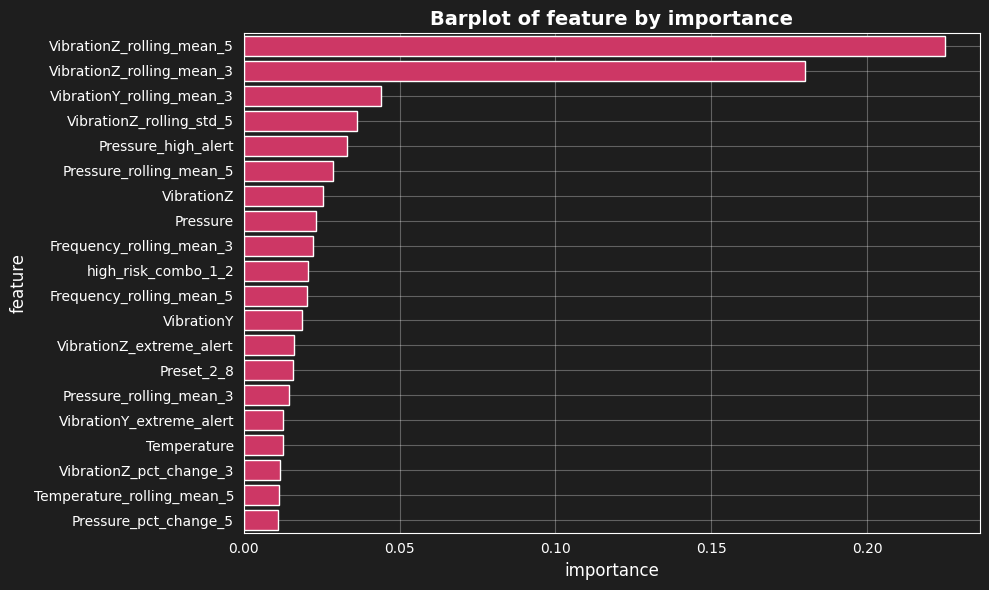

```python
# Get importances
importance_df = get_rf_feature_importance(pipeline, X_train, y_train)

# Plot top 20
fig = DataPlotter().plot_bar(importance_df.head(20), y='feature', x='importance')
```

**Top Features** - vibrations related variables

**VibrationY & VibrationZ most relevant** → especially their rolling means

**Alert flags (`high_alert`, `extreme_alert`) contribute meaningfully**